# Detailed model formulation, analysis, and results

**Supporting Information for:** Developing a protocol for estimation of red deer (*Cervus elaphus*) population density using drones in a steep and rugged terrain

Author

Published

April 9, 2025

This document presents a detailed model description, details about the model results, including convergence diagnostics, posterior predictive checks, tables and figures. The document is written in Quarto, and the source file containing all executable R code is available in the GitHub-repository accompanying the paper (<zip-file provided for per review>).

# 1 Detailed model formulation

Deer densities were estimated using hierarchical state space models fitted by the use of Bayesian Markov Chain Monte Carlo (MCMC) sampling in NIMBLE ver. 1.3.0 (Perry de Valpine et al. 2017, 2024). We combined a double-observer observation model with an overdispersed Poisson process model describing the variation in deer densities among sampling sites (focal images). We will here first derive the observation model and the process model, using a hierarchical formulation, and then provide details about the analysis. The NIMBLE model code, together with the data, are provided on GitHub (<URL will be inserted after peer-review; a zip-file is provided for peer-review>).

To estimate abundance and population density, one must account for the fact that not all individuals that are present will be observed (i.e., imperfect detection). Detection failure can be due to either individuals being hidden (e.g, under trees) and hence not available for registration in the images, or because they were missed by the observers while inspecting the images even though they were present (available for detection) in the images (Brack, Kindel, and Oliveira 2018). By comparing registrations from multiple overlapping images, we found that it was very unlikely that an individual would be completely hidden in all overlapping images (see main text), and hence we did not account for imperfect availability. However, it was not uncommon that an individual registered by one observer was missed by the other observer. Hence, we used a double observer protocol to estimate detection probabilities (Nichols et al. 2000; Williams, Nichols, and Conroy 2002):

At each site (focal image) $i$ we have records of how many individuals that were seen by only observer 1 ($y_{10,i}$), how many individuals were seen by only observer 2 ($y_{01,i}$), and how many individuals were seen by both observers ($y_{11,i}$). We denote the observed data from each site by a vector $\mathbf{y}_i = \left[y_{01,i},y_{10,i},y_{11,i} \right]$, and the number of individuals seen by at least one observer is the sum of the elements in this vector, $\mathbf{Y}_i = y_{01,i} + y_{10,i} + y_{11,i}$. The observation model defined in the first section below describes the probability (likelihood) of getting these observed data, conditional on the number of individuals ($N_i$) present at each site; i.e. $L(\mathbf{y}_i |N_i)$. The number of individuals at each site, $N_i$, is unknown, and the stochastic model for this is described in the next section.

## 1.1 Observation model

Given that the two observers detect individuals independently with probabilities $p_1$ and $p_2$ respectively, the probability that an individual is detected by only observer 1 is $P_{10} = p_1 (1-p_2)$, the probability of only being detected by observer 2 is $P_{01} = (1-p_1)p_2$, and the probability of being detected by both observers is $P_{11} = p_1 p_2$. The probability of being detected by at least one observer is one minus the probability of not being detected by any of the observers, $p^* = 1-(1-p_1)(1-p_2)$. Note that this is equivalent to $p^* = P_{10} + P_{01} + P_{11}$.

The key to derive a model for the observed data ($L(\mathbf{y}_i│N_i)$), is to first write the probability of the observed data conditional on the number of individuals seen by at least one observer ($Y_i$), and then multiply this with the probability of observing $Y_i$. I.e., $L(\mathbf{y}_i│N_i) = L(\mathbf{y}_i|Y_i)L(Y_i|N_i)$. The first of these components is a multinomial likelihood, and the second component is a binomial likelihood. Hierarchically, we write this as

$$\begin{align}
\mathbf{y}_i &\sim \text{Multinomial} (\pi,Y_i) \\
Y_i &\sim \text{Binomial}(p^*,N_i)
\end{align}$$

where $\pi=[P_{10},P_{01},P_{11} ]/p^*$ (i.e., the multinomial probability vector $\pi$ contains the probabilities of the three detection categories conditional on detection). Note that all observed individuals must belong to one, and only one, of the three detection categories, and hence the elements of $\pi$ sum to one. Note also that when $Y_i=0$, the multinomial probability of observing $\mathbf{y}_i=[0,0,0]$ becomes 1 regardless of the parameter values.

This initial observation model has only two top level parameters: the detection probabilities of the two observers, $p_1$ and $p_2$ (these could have been made site specific, and then been modelled as a function of covariates on e.g. a logit scale). Posterior predictive checks (see below) indicated, however that the two independent observers had sufficiently variable detection probabilities among sites to call for a model with random detection probabilities – see details in Section 2.2.

## 1.2 Process model

The number of individuals present at a site was modelled as an overdispersed Poisson process. Hence, we assume that number of individuals present at site $i$, $N_i$, is drawn from a Poisson distribution with expectation $\lambda_i a_i$, where $\lambda_i$ is the expectation per unit area (we used hectares) and $a_i$ is the area of the site,

$$N_i \sim \text{Poisson}(\lambda_i a_i)$$

Overdispersion was accommodated by modelling $\lambda_i$ as a random variable. As we anticipated that density estimates may be somewhat sensitive to the choice of the distribution of $\lambda_i$, we examined three alternative random distributions; log-normal, exponential, and gamma.

### 1.2.1 Log-normal expectation

For the log-normal model we used a standard log-linear log-normal model,

$$\begin{align}
\log(\lambda_i) &\sim N(\mu_i, \sigma^2) \\
\mu_i &= x_i \beta
\end{align}$$

where $x_i$ is a vector of site-covariates and $\beta$ is a vector of the linear coefficients (including an intercept). Mean deer density in the log-normal model is then $e^{\mu_i+\sigma^2/2}$ and the variance is $(e^{\sigma^2}-1) e^{2\mu_i+\sigma^2}$.

### 1.2.2 Exponential expectation

The exponential distribution is a one-parameter distribution with probability density function $f(\lambda) = \Lambda e^{-\Lambda\lambda}$, expectation $1/\Lambda$, and variance $1/\Lambda^2$. We modeled the expectation as a log-linear function of covariates (i.e., assuming multiplicative effects), and hence formulated the model hierarchically as

$$\begin{align}
\lambda_i &\sim \text{Exponential}(\Lambda_i) \\
\Lambda_i &= e^{-\mu_i} \\
\mu_i &= \mathbf{x}_i \boldsymbol{\beta}
\end{align}$$

Mean deer density in the exponential model thus becomes $e^{\mu_i}$ and the variance is $e^{2\mu_i}$.

### 1.2.3 Gamma expectation

The gamma distribution parameterized with a shape parameter $a$ and a rate parameter $b$ has probability density function $f(\lambda) = \frac{b^a}{\Gamma(a)} \lambda^{a-1} e^{-\beta\lambda}$, expectation $\frac{a}{b}$, and variance $\frac{a}{b^2}$ (the variance is proportional to the mean). We initially tried keeping the rate parameter constant and using a log-linear covariate model for the expectation (i.e., $a_i = be^{\mathbf{x}_i\boldsymbol{\beta}}$), but this model had very poor mixing, even when using blocked mcmc-sampling (perhaps because $b$ is a parent of $a$). Hence, we instead kept the shape parameter constant and let the rate parameter depend on $\mu_i$ and $\sigma$ in such a way that the variance-mean relationship is the same as in the log-normal model (the variance is proportional to the square of the mean),

$$\begin{align}
\lambda_i &\sim \text{Gamma}(a,b_i) \\
b_i &= ae^{-(\mu_i+\sigma^2/2)} \\
a &= \frac{1}{e^{\sigma^2} - 1} \\
\mu_i &= \mathbf{x}_i \boldsymbol{\beta}
\end{align}$$

Hence, mean and variance of deer density in the gamma model has the same expressions as in the log-normal model, respectively $\frac{a}{b} = e^{\mu_i+\sigma^2/2}$ and $a/b^2 = \left( e^{\sigma^2}-1 \right) e^{2\mu_i+\sigma^2 }$. Compared to the log-normal distribution with the same mean and variance, the gamma distribution has a higher density close to zero and a lower density far out in the tail of the distribution.

## 1.3 Modelling of covariate effects

In our application, we included the distance from the agricultural field as the only site covariate in $\mathbf{x}_i$. The covariate effect was the same in all sampling area-month combinations, but the intercept was allowed to vary across area-months. Denoting the index for the area-month that site $i$ belongs to as $j(i)$, we can formulate the covariate model as,

$$\mu_i = \mu_{0,j(i)} + x_i \beta$$

In principle, $\mathbf{x}_i$ can include both covariates that vary among sites within sampling areas and covariates that vary only among, and not within, sampling areas. However, it is important to realize that if $\mathbf{x}_i$ includes sampling area covariates, random effects of sampling areas would need to be included in order to avoid pseudoreplication (sites within sampling areas is not a random sample of sites with the same sampling area covariate value).

# 2 Modeling focus and strategy

## 2.1 Specification of priors and starting values

For the observation model parameters $p_1$ and $p_2$ (detection probabilities) we initially used $\text{Uniform}(0,1)$ priors. However, as posterior predictive checks indicated that random effects on detection probabilities were required, we decided to use logit-normal priors for detection probabilities (see Section 2.2). We also used data from trials at a deer enclosure in a natural habitat to inform the priors for these parameters (see Section 2.3).

The covariate (distance from field) was normalized by subtracting the mean and dividing by the standard deviation prior to model fitting, and we used a $\text{N}(0,\sigma=2)$ prior for the covariate effect, $\beta$.

One approach to the modelling could have been to specify somewhat informative priors for the intercepts $\mu_{0,j(i)}$ based on prior knowledge of reasonable deer densities in the area. However, due to the methodological nature of our study, we decided to use essentially uninformative priors for $\mu_{0,j(i)}$, $\text{N}(0,\sigma=10)$.

To find reasonable starting values for the MCMC-chains, we first computed estimates of $p_1$ and $p_2$ as the proportion of those individuals that were seen by observer 2 that were also seen by observer 1 and vice versa. Simplified estimates of population densities were then computed from the deer counts, the estimated areas of the sites, and the initial estimates of $p_1$ and $p_2$ (see code for details <link to GitHub repository will be inserted after peer review>).

For the log-normal and the gamma models, the prior distribution for $\sigma$ was specified as

$$\sigma \sim \text{Gamma}(\text{shape} = 0.01, \text{ rate} = 0.01)$$

In Section 3.3.8, we present computed overlap between prior and posterior distributions for all parameters.

## 2.2 Posterior predictive checks and model modifications

We performed posterior predictive checks (Gelman et al. 2004; Conn et al. 2018) with respect to both $Y_i$’s and $\mathbf{y}_i$’s by comparing the sum of the squared Pearson residuals (discrepancy measure) for observed and simulated data in every step of the MCMC-chains. Bayesian p-values (proportion of the discrepancy measure that are larger for the simulated data than for the observed data) did not indicate any lack of fit with respect to $Y_i$’s ($p > 0.4$), but there appeared to be a lack of fit with respect to $\mathbf{y}_i$’s ($p < 0.03$), indicating that there were more variation in the counts from the two independent observers than expected if detection probability was constant across sites for each observer. To accommodate this variation in the model, we introduced random detection probabilities, assuming the logit-transformed detection probabilities to be normal. Hence, in our final observation model, we used

$$\begin{align}
p_{1,i} &= \frac{1}{1+e^{-(\eta_1 + \epsilon_{1,i})}} \\
p_{2,i} &= \frac{1}{1+e^{-(\eta_2 + \epsilon_{2,i})}} \\
\epsilon_{1,i} &\sim \text{N}(0,\sigma_p)\\
\epsilon_{2,i} &\sim \text{N}(0,\sigma_p)\\
\end{align}$$

A model with a wide prior for $\sigma_p$ resulted in unreasonable high upper values; the high prevalence of $Y_i = 0$ in the data could be explained by either a high number of sites having very low expected densities (which is reasonable) or a high number of sites having very low detection probabilities (which is *not* reasonable). Hence, to facilitate model fitting, we used a somewhat informative prior for $\sigma_p$; a Gamma-prior truncated at an upper bound of 0.59,

$$\sigma_p \sim\text{T} \left[ \text{Gamma}(1,0.05), 0, 0.59 \right]$$

The upper bound of $0.59$ was set based on a prior assessment that detection at the 97.5 percentile site should have a maximum of 10 times higher odds than in the 2.5 percentile site ($\log(10)/(1.96 \times 2) \approx 0.59$). In Section 3.3.9.3 we investigate the sensitivity of our results with respect to the choice pf prior for $\sigma_p$.

Bayesian p-values did not indicate any lack of fit of this final model with respect to $Y_i$’s ($p = 0.50$) or $\mathbf{y}_i$’s ($p = 0.19$) (see Section 3.3.6).

## 2.3 Using data from the deer enclosure to inform priors on detectability

The enclosure surrounded a natural habitat with a similar forest type as at the sampling areas. It is therefore reasonable to assume that detection probabilities inside and outside the enclosure are similar. It is, however, not reasonable to assume that the variation in deer densities among sites (focal images) are similar because the enclosure had much higher density, much more females than males, many young individuals, and there were feeding stations where the deer tended to aggregate.

Initial analysis showed that there was no significant difference in detection probability in the enclosures for the two observers, and we hence simplified the observation model to have the same mean logit-scale detection probability for the two observers, $\eta_1 = \eta_2 = \eta$. The model was then fitted with the following uninformative prior:

$$\eta \sim \text{N}(0,2) \\$$

When fitting the full model to the data from the sampling areas, we used as priors

$$\begin{align}
\eta_1 &\sim \text{N}\left(\text{mean}(\boldsymbol{\eta}), 1.5\text{sd}(\boldsymbol{\eta})\right) \\
\eta_2 &\sim \text{N}\left(\text{mean}(\boldsymbol{\eta}), 1.5\text{sd}(\boldsymbol{\eta})\right) \\
\end{align}$$
where $\text{mean}(\boldsymbol{\eta})$ and $\text{sd}(\boldsymbol{\eta})$ refer to the mean and standard deviation of the posterior samples for $\eta$ in the enclosure model. The posterior standard deviations were conservatively increased by 50% to account for the fact that detection probabilities inside and outside of the enclosure could be different. See Section 3.2.3 for details.

## 2.4 Implementation and model selection

The models were fitted by the use of Bayesian MCMC sampling in NIMBLE (v1.3.0; (P. de Valpine et al. 2024; Perry de Valpine et al. 2017)). Convergence was assessed on three independent MCMC chains (with different start values) with the Gelman and Rubin (1992) diagnostics using the ‘gelman.diag-function’ in the ‘coda’ package ver. 0.19-4.1 (Plummer et al. 2006) in R ver. 4.3.3 (R Core Team 2024).

For each of the three models for the random Poisson expectation (log-normal, exponential and gamma), we fitted both linear and quadratic models for $\mu_i$ as a function of distance from the field, as well as a model with no covariate effects; hence obtaining 9 models. We selected the best model according to the Watanabe-Akaike (Widely Applicable) Information Criterion, WAIC (Watanabe 2010) for presentation of estimates and prediction (the criterion seeks to minimize the prediction error variance as an optimal trade-off between accuracy and precision of the fitted model predictions).

## 2.5 Estimating densities at the specific sites included in each survey

The estimators for mean density presented in Section 1.2 assume that the sites are random samples of a large number of sites of the same characteristics, and the estimates apply to this statistical population of sites. We also computed estimates of density (at the time of flight) at the specific sites included in each survey as the estimated number of individuals present divided by the total area covered, $\bar{d}_s =\sum_{i=1}^n \hat{N}_i/\sum_{i=1}^n a_i$ (the sums are over all $n$ sites in the survey and the subscript $s$ in $\bar{d}_s$ indicates that the mean only applies to the specific sites sampled).

## 2.6 Estimating number of deer in a specific area

When estimating number of deer in a specific area, such as in the deer enclosures, simply computing the posterior of $N_{\text{Tot}} = \bar{d}_s/q$ were $\bar{d}_s$ is the mean density at the surveyed sites (Section 2.5) and $q$ is the proportion of the area included in survey, will underestimate the sampling variance (uncertainty) of the total number of deer in the area since density in the sampled and unsampled part of the area would not be exactly the same.

To compute the sampling variance of mean number of deer at sample units, we must account for the fact that we sample from a finite area without replacement. It is not straightforward to do this in a Bayesian setting (Banerjee 2024), and our case is further complicated by the fact that sample sites vary in size (particularly in the deer enclosures, where parts of the focal images were outside the enclosures). Hence, since we only have a finite sampling area in the deer enclosure, and we only estimate number of deer in the enclosure as a proof of concept, we took a more frequentist approach to the problem, ignoring the fact that sites are of different sizes:

If $n$ sites are sampled from an area covering $K$ sites, the standard expression for the sampling variance of the mean number of deer in the $K$ sites is
$$\text{Var}(\bar{N}) = \frac{K-n}{K} \frac{s^2}{n}$$
where $s^2$ is is the empirical variance in number of individuals per site. The first factor is the proportion of the $K$ sites that are *not* included in the sample, and the variance becomes zero when we have counts of the entire area (when $n = K$).

The total number of deer in the area is $N_{\text{Tot}} = K\bar{N}$ with sampling variance $\text{Var} \left( N_{\text{Tot}} \right) = K^2 \text{Var} \left( \bar{N} \right)$. Replacing with the proportion of the area covered in the sample, $q = n/K$, and inserting the expression for $\text{Var}(\bar{N})$ above, we get

$$\text{Var} \left( N_{\text{Tot}} \right) = \left( \frac{n}{q} - n \right) \frac{s^2}{q}$$
(see also Williams, Nichols, and Conroy (2002) chap. 12.4.1).

In our situation, we do not have exact counts of number of deer per site (due to imperfect detection), but instead we have posterior samples of $N_i$ at each site $i$. To assess the uncertainty in $N_{\text{Tot}}$, we computed posterior samples for lower and upper 95% confidence limits assuming a normal distribution (by the central limit theorem) at the log-scale, using the delta-method approximation,

$$\text{CI} = \exp(\log(N_{\text{Tot}}) \pm 2 N_{\text{Tot}}^{-1}s)$$

In the analysis of the deer enclosure data, we were not interested in describing the variation among sites, and therefor instead specified uninformative priors for the true number of deer at each site hierarchically as

$$\begin{align}
N_i &\sim \text{Poisson}(\lambda_i) \\
\lambda_i &\sim \text{Uniform}(0, 50) \\
\end{align}$$

# 3 Detailed analysis and results

## 3.1 Organization of the data

All data are in the `data` folder of the repository. The data-files included here are:

- `SiteData.rda`: The full data from the study sites (excluding enclosure). See `SiteDataInfo.html` for description of the variables.
- `CountData.rda`: Based on `SiteData.rda`, but includes only counts in a long format.
- `CountData_Fence.rda`: Counts in a long format from the enclosure.
- `nimbleData.rda`: Data from the study sites organized for NIMBLE models. File is produced by the script in `data\Make_nimbleData.R`.
- `nimbleData_Fence.rda`: Data from the enclosure organized for NIMBLE models. File is produced by the script in `data\Make_nimbleData_Fence.R`.

## 3.2 Enclosures

The enclosure contained a total of 117 red deer in a 5 hectare area of natural forest. Two survey flights were conducted over the enclosures; one at 40 m above ground, and one at 60 meter above ground. We used these data to first test the method, and then to obtain information about detection probabilities, which we used to inform priors for detection probabilities in the models fitted to the wild deer data.

### 3.2.1 Overview of data

**Area of the sampling sites in hectare (ha); rows represent survey at 40 m and 60 m above ground respectively:**

```
                             1     2     3     4     5     6     7     8     9
20210307_Fencing_RGB_40m 0.350 0.326 0.293 0.301 0.303 0.172 0.013 0.302 0.346
20210307_Fencing_RGB_60m 0.246 0.195 0.193 0.203 0.002 0.009 0.130 0.141 0.185
                            10    11    12    13   14    15    16    17    18
20210307_Fencing_RGB_40m 0.340 0.345 0.352 0.371 0.31 0.188 0.101 0.024 0.021
20210307_Fencing_RGB_60m 0.265    NA    NA    NA   NA    NA    NA    NA    NA
                            19    20
20210307_Fencing_RGB_40m 0.014 0.005
20210307_Fencing_RGB_60m    NA    NA
```

The reason why some sites cover a much smaller area than other sites is that large parts of these sites (focal images) were outside the enclosure. The survey from 40 m above ground contained data from 20 non-overlapping sites, covering a total of 4.48 ha (90% of the 5 ha enclosure). The survey from 60 m above ground contained data from 10 non-overlapping sites, covering a total of 1.57 ha (31% of the enclosure). The reason for the lower overall coverage from the 60 m survey is that larger proportions of the focal images from this survey covered ground outside of the enclosure.

**Counts at 40 m,** $\mathbf{y}_i$ for each site (column) $i$ (rows: first number of deer detected by only observer 1, then number of deer detected by only observer 2, and finally number of deer detected by both observers):

```
        1 2 3 4  5  6 7 8 9 10 11 12 13 14 15 16 17 18 19 20
only_ab 0 0 1 5  4  0 0 0 0  1  0  0  0  0  0  0  0  0  0  0
only_jb 0 0 2 4  6  0 0 0 0  0  1  0  0  0  0  1  0  0  0  0
both    0 0 2 5 25 12 0 0 0  0  0  0  0  2  0  0  0  0  0  0
```

**Counts at 60 m:**

```
        1 2 3 4 5 6 7 8  9 10
only_ab 1 1 3 0 0 0 0 0  5  0
only_jb 1 1 0 0 0 0 0 0  1  1
both    0 2 5 0 0 0 1 3 12  4
```

### 3.2.2 Deer numbers

The NIMBLE-model to estimate total number of deer in the enclosure (see Section 2.6) is defined in `R/nimble_models/enclosure_model_N.q` and the model is fitted with the script in `R/run_enclosure_model_N.R` (see the script for mcmc trace plots, convergence diagnostics and posterior predictive checks).

**Summary of posterior distributions:**

```
Iterations = 1:20000
Thinning interval = 1
Number of chains = 3
Sample size per chain = 20000

1. Empirical mean and standard deviation for each variable,
   plus standard error of the mean:

               Mean     SD  Naive SE Time-series SE
N_sum[1]    74.1866 2.2919 0.0093568       0.031415
N_sum[2]    42.7034 1.6195 0.0066117       0.017952
N_tot[1]    82.8033 2.5581 0.0104436       0.035064
N_tot[2]   136.1121 5.1621 0.0210741       0.057220
N_lower[1]  59.2949 2.2073 0.0090111       0.030687
N_lower[2]  68.1236 3.7530 0.0153214       0.040290
N_upper[1] 115.6390 2.9567 0.0120706       0.038901
N_upper[2] 272.0958 8.4520 0.0345050       0.073830
eta[1]       1.2741 0.3082 0.0012581       0.007189
eta[2]       1.3994 0.3568 0.0014565       0.006676
sigma_p      0.4091 0.1348 0.0005504       0.004798

2. Quantiles for each variable:

               2.5%      25%      50%      75%    97.5%
N_sum[1]    71.0000  73.0000  74.0000  75.0000  80.0000
N_sum[2]    41.0000  41.0000  42.0000  43.0000  47.0000
N_tot[1]    79.2466  81.4789  82.5950  83.7111  89.2919
N_tot[2]   130.6828 130.6828 133.8702 137.0576 149.8071
N_lower[1]  56.2978  57.5210  58.9315  60.4565  64.6580
N_lower[2]  64.4909  64.4909  67.2939  69.9641  77.8174
N_upper[1] 111.5499 113.4792 115.1536 117.2773 122.7774
N_upper[2] 264.8124 264.8124 269.6509 276.2757 293.5380
eta[1]       0.6781   1.0686   1.2709   1.4771   1.8914
eta[2]       0.7069   1.1539   1.3904   1.6445   2.1011
sigma_p      0.1037   0.3198   0.4377   0.5211   0.5837
```

Here, the indices 1 or 2 in brackets represent survey at 40 m and 60 m respectively. `N_sum` is the sum of individuals in the surveyed sites (see section Section 2.5). `N_tot` is the estimated total number of deer in the enclosure, $N_\text{Tot}$, as defined in section Section 2.6. The posterior distribution for this random variable is too narrow as it assumes that density in the parts of the enclosure that has not been surveyed is exactly the same as in the surveyed part of the enclosure. `N_lower` and `N_upper` are the confidence limits derived in Section 2.6. Finally, the three last parameters are the mean and standard deviation of the logit scale detection probabilities.

Judging by the posterior median, the approximate frequentist confidence intervals derived in Section 2.6 marginally fail to cover the true known number of deer in the enclosure (117 deer) in the 40 m above ground survey (confidence interval range from about 59 to 115 individuals). The true value is however included in the much wider confidence interval for the 60 m above ground survey (confidence interval range from about 67 to 270 individuals). Even though the credible intervals for the number of deer at the surveyed sites (posterior distributions for `N_sum`) were not discouragingly wide, the confidence intervals for the total number of deer in the enclosure (based on `N_lower` and `N_upper`) were rather wide, particularly for the 60 m above ground survey. This is due to the clustered distribution of deer within the enclosure, combined with somewhat limited sampling effort. Estimates from multiple surveys could have been combined to gain precision (not included here).

### 3.2.3 Detection probabilities

The surveys of the sampling sites in the wild population were conducted with flights at 60 m above ground. Hence, we used the posterior distribution of `eta[2]` to inform priors for detection probabilities in the models fitted to these data. Transforming `eta[2]` to the probability scale gives a posterior median detection probability of 0.80 and a 95% credible interval ranging from 0.67 to 0.89 (see also Figure 2).

The posterior distribution of `eta[2]` is plotted in Figure 1 (black and red) and the corresponding posterior distribution for detection probability at the median site is plotted in Figure 2. As a prior for `eta[2]` in the analysis of the wild deer data from the sampling sites (blue lines), we used a normal distribution with the same mean and 1.5 times the standard deviation of the posterior samples from the model fitted to the enclosure data.

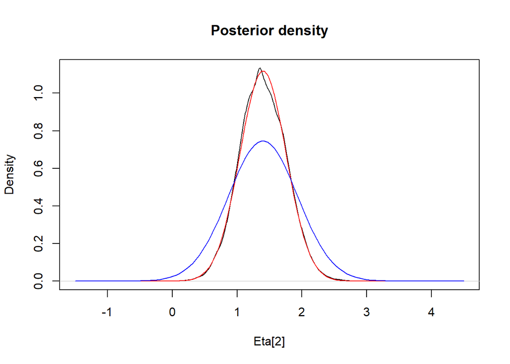

Figure 1: The distribution of the posterior samples of `eta[2]` (black), the normal distribution with the same mean and standard deviation as the posterior samples (red), and the normal distribution with the same mean and 1.5 times the standard deviation of the posterior samples (blue). The latter distribution (in blue) was used as a prior for `eta[2]` in the models fitted to the survey data from the wild populations.

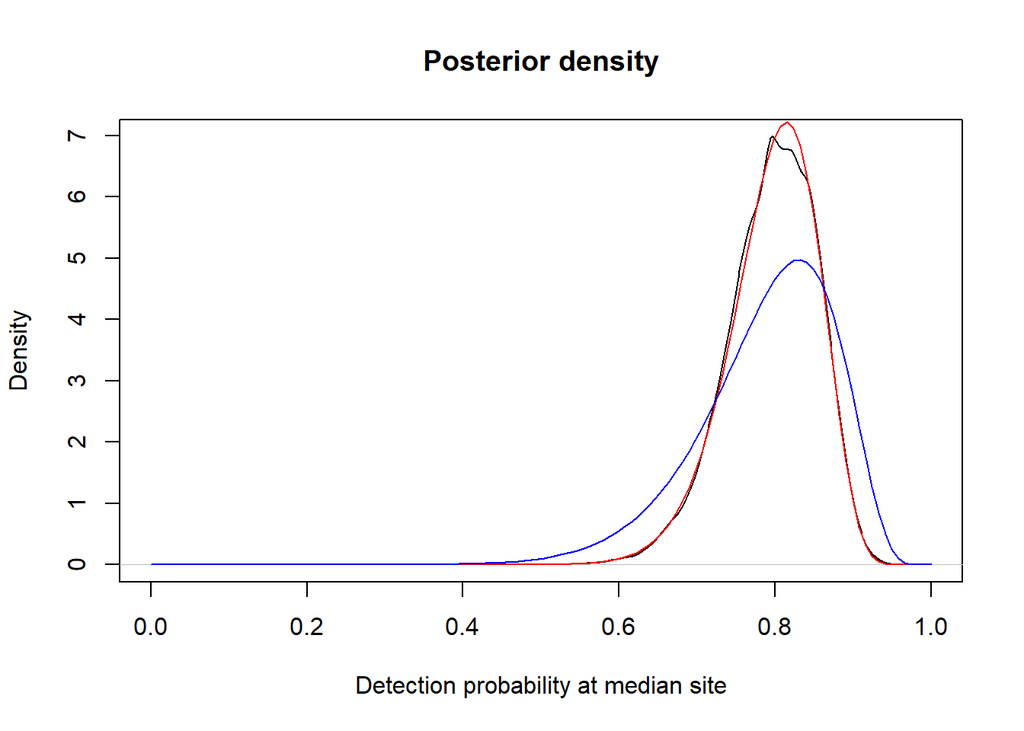

Figure 2: The distributions of `eta[2]` transformed to the probability scale (i.e., detection probabiity at the median site). Colour codes are the same as in Figure 1.

The posterior distribution of `sigma_p` is shown in Figure 3 (note that there is a prior upper bound at 0.59; see Section 2.2 for prior specification). In Figure 4, this posterior distribution is transformed to the posterior distribution for the odds-ratio for detection at the 97.5 percentile site versus the 2.5 percentile site.

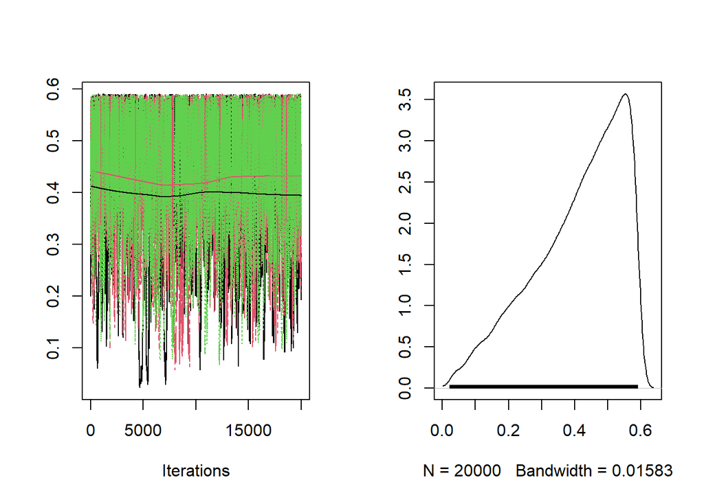

Figure 3: Trace plot (left) and density plot (right) of posterior samples of `sigma_p`. The range of the posterior samples is shown as a thick line in the density plot.

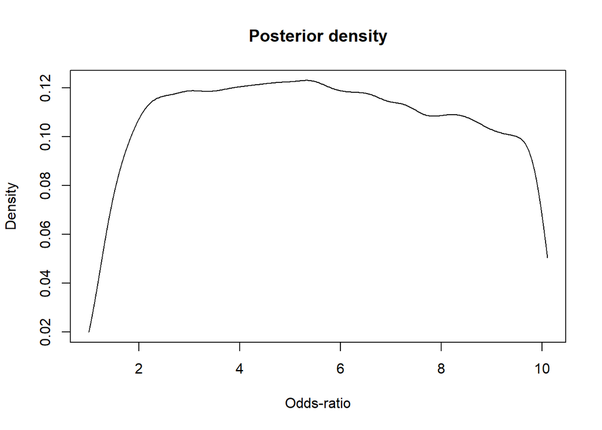

Figure 4: Posterior distribution for the odds-ratio for detection at the 97.5 percentile site versus the 2.5 percentile site

Including random effects on detection probability was deemed necessary by posterior predictive checks (Section 2.2), but there is obviously little information in the data to estimate heterogeneity in detection probability among sites. We also expect that the `sigma_p` parameter may be confounded with heterogeneity in actual density among sites (Section 2.2).

## 3.3 Wild deer

### 3.3.1 Overview of data

The full data are in the `SiteData.rda` files, with variables described in `SiteDataInfo.html`. Table 1 gives an overview of the data from the four sampling areas and two sampling periods (March and April).

| Sample area, month | Flight altitude (m) | Number of sites | Mean area of sites (ha) | SD of site area | Total area (ha) | Number seen only by obs. 1 | Number seen only by obs. 2 | Number seen by both observers | Number seen in total | Simple estimate of density (ha$^{-1}$) |
| --- | --- | --- | --- | --- | --- | --- | --- | --- | --- | --- |
| Haugen, March | 60 | 43 | 0.65 | 0.07 | 28.07 | 1 | 2 | 11 | 14 | 0.511 |
| Haugen, April | 60 | 24 | 0.66 | 0.07 | 15.75 | 0 | 1 | 11 | 12 | 0.780 |
| Raa, March | 40 | 35 | 0.30 | 0.08 | 10.58 | 0 | 0 | 0 | 0 | 0.000 |
| Raa, April | 40 | 24 | 0.22 | 0.03 | 5.36 | 0 | 0 | 0 | 0 | 0.000 |
| Søre Bjørkum, March | 60 | 87 | 0.75 | 0.21 | 64.88 | 0 | 11 | 12 | 23 | 0.363 |
| Søre Bjørkum, April | 40 | 40 | 0.59 | 0.18 | 23.40 | 2 | 1 | 1 | 4 | 0.175 |
| Sprakehaug, March | 60 | 31 | 0.60 | 0.06 | 18.64 | 0 | 1 | 1 | 2 | 0.110 |
| Sprakehaug, April | 60 | 17 | 0.60 | 0.05 | 10.20 | 0 | 0 | 0 | 0 | 0.000 |

Most areas where surveyed by drone flights at 60 meter altitude above ground (pre-programmed based on a digital elevation model), but some areas where surveyed by flights at 40 meters above ground. Considerable variation in size of the sampling sites, among and within sampling areas, also occurred due to the steep and rugged terrain (Figure 5).

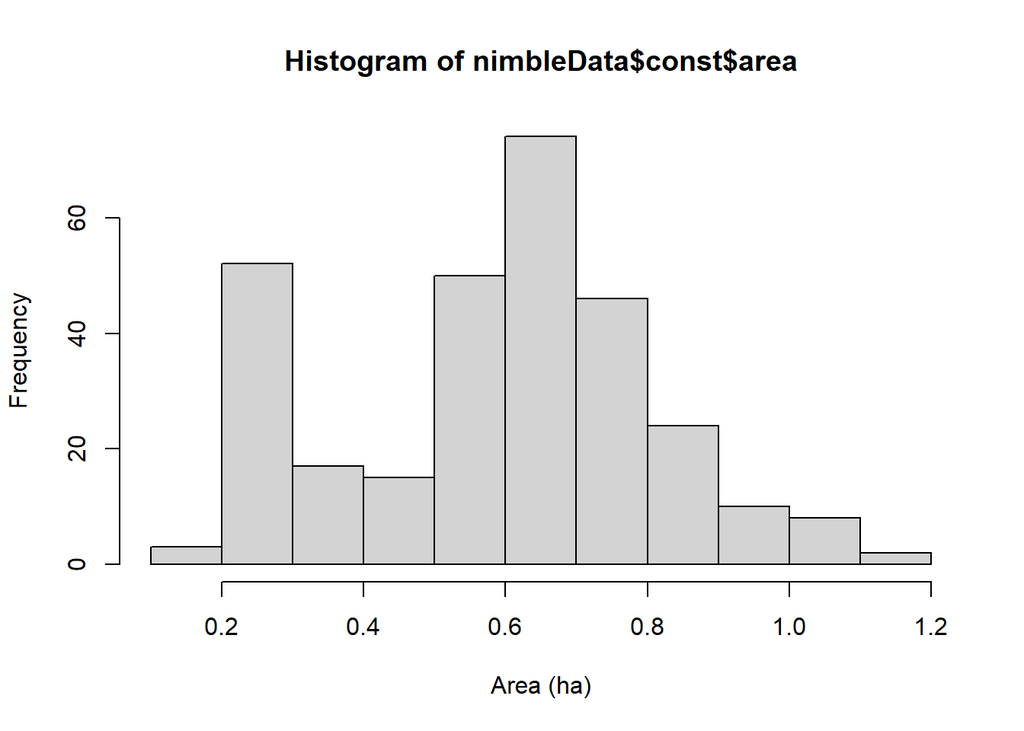

Figure 5: Histogram of area of of the sampling sites.

Deer were seen at 27 of the 301 sites, and the number of deer per site were distributed as follows

```r
table(nimbleData$data$Y)
```

```
  0   1   2   3   5   7
274  10  12   3   1   1
```

(I.e, there were 274 sites with zero deer seen, 10 sites with 1 deer, and so on).

The mean number of deer per site was 0.18 and the variance was 0.5 (the variance-mean ratio is 2.72). This shows that there is considerable overdispersion in number of deer per site relative to a Poisson distribution.

### 3.3.2 Simple estimates for MCMC staring values

Simple point estimate of detectability based on how many of those seen by observer 1 is seen by observer 2 and vice versa can be computed as follows:

```r
colsumy <- apply(nimbleData$data$y, 3, sum, na.rm=TRUE)
p1hat <- colsumy[3]/(colsumy[2]+colsumy[3]) # = 0.692
p2hat <- colsumy[3]/(colsumy[1]+colsumy[3]) # = 0.923
(phat_simple <- 1 - (1-p1hat)*(1-p2hat))
```

```
     both
0.9763314
```

This is the probability that at least one of the two observers registered a given deer in the picture (obs1 has probability 0.7 and obs2 has probability 0.9).

Simple density estimates based on number of deer seen divided by total area, corrected for detection probability <1 (number of deer per hectare (1/100 km$^2$)):

```r
(lambdahat <- (Y_per_sam/phat_simple)/area_per_sam)
```

```
      Haugen (April)       Haugen (March)          Raa (April)
           0.7804950            0.5107558            0.0000000
         Raa (March) Søre Bjørkum (April) Søre Bjørkum (March)
           0.0000000            0.1750525            0.3631129
  Sprakehaug (April)   Sprakehaug (March)
           0.0000000            0.1098906
```

### 3.3.3 WAIC model selection

Table 2 shows the WAIC values for the nine candidate models (see Section 1.2). The log-normal and gamma models give a significantly better fit to the data than the exponential models. The gamma models are slightly better (lower WAIC) than the log-normal models, but there is very little difference between the three gamma models. We will focus our inference on the `gamma_0` (no covariate effect) and `gamma_2` (a quadratic covariate effect) models.

Table 2: WAIC values for the nine candidate models. Indices 0-2 refer to models without covariate effect (0), models with a linear effect of distance from the field (1), and models with a quadratic effect of distance from the field (1).

| model | WAIC |
| --- | --- |
| exponential_0 | 122.84 |
| exponential_1 | 122.28 |
| exponential_2 | 121.48 |
| lognormal_0 | 113.68 |
| lognormal_1 | 113.64 |
| lognormal_2 | 113.79 |
| gamma_0 | 112.32 |
| gamma_1 | 112.40 |
| gamma_2 | 112.37 |

### 3.3.4 Summary of the WAIC-best models

**Summary of the posterior samples from the `gamma_0` model:**

```
Iterations = 1:30000
Thinning interval = 1
Number of chains = 3
Sample size per chain = 30000

1. Empirical mean and standard deviation for each variable,
   plus standard error of the mean:

            Mean     SD  Naive SE Time-series SE
mu0[1]   -1.0704 0.7483 0.0024943       0.003031
mu0[2]   -1.7099 0.5662 0.0018874       0.002955
mu0[3]  -10.1353 5.7643 0.0192144       0.179622
mu0[4]  -10.8694 5.7181 0.0190603       0.208475
mu0[5]   -2.8287 0.7452 0.0024839       0.003891
mu0[6]   -2.0824 0.4167 0.0013890       0.002950
mu0[7]  -10.2581 5.4858 0.0182860       0.128556
mu0[8]   -3.3936 0.9820 0.0032734       0.005852
sigma     1.4934 0.1040 0.0003467       0.001906
eta1      1.0726 0.2385 0.0007949       0.007906
eta2      1.8295 0.2890 0.0009633       0.012143
sigma_p   0.3862 0.1547 0.0005156       0.011353

2. Quantiles for each variable:

            2.5%      25%    50%     75%   97.5%
mu0[1]   -2.4131  -1.5708 -1.111 -0.6261  0.5313
mu0[2]   -2.8087  -2.0870 -1.717 -1.3437 -0.5791
mu0[3]  -23.9575 -13.4812 -8.942 -5.6965 -2.3891
mu0[4]  -24.4236 -14.0446 -9.717 -6.5018 -3.2194
mu0[5]   -4.3346  -3.3146 -2.814 -2.3321 -1.3956
mu0[6]   -2.9169  -2.3564 -2.076 -1.8024 -1.2802
mu0[7]  -23.5083 -13.3408 -9.121 -6.0887 -2.8083
mu0[8]   -5.4705  -4.0037 -3.346 -2.7326 -1.5899
sigma     1.2824   1.4254  1.495  1.5643  1.6926
eta1      0.6226   0.9086  1.069  1.2311  1.5524
eta2      1.3038   1.6235  1.820  2.0322  2.3944
sigma_p   0.0610   0.2789  0.422  0.5169  0.5835
```

**Summary of the posterior samples from the `gamma_2` model:**

```
Iterations = 1:30000
Thinning interval = 1
Number of chains = 3
Sample size per chain = 30000

1. Empirical mean and standard deviation for each variable,
   plus standard error of the mean:

            Mean     SD  Naive SE Time-series SE
mu0[1]   -1.1061 0.7304 0.0024348       0.003038
mu0[2]   -1.6833 0.5553 0.0018511       0.002872
mu0[3]   -9.2050 5.7448 0.0191493       0.174775
mu0[4]  -10.0699 5.9788 0.0199295       0.236475
mu0[5]   -3.2834 0.8169 0.0027228       0.005289
mu0[6]   -1.8971 0.5569 0.0018562       0.004096
mu0[7]  -10.6245 5.7033 0.0190109       0.143465
mu0[8]   -3.7387 1.0505 0.0035017       0.007095
beta[1]   0.9325 0.4398 0.0014659       0.004414
beta[2]  -0.3060 0.2721 0.0009070       0.002708
sigma     1.4750 0.1066 0.0003553       0.002001
eta1      1.0791 0.2535 0.0008450       0.008405
eta2      1.8080 0.2777 0.0009256       0.010057
sigma_p   0.4150 0.1301 0.0004335       0.007140

2. Quantiles for each variable:

            2.5%      25%     50%     75%   97.5%
mu0[1]   -2.4443  -1.5935 -1.1409 -0.6618  0.4391
mu0[2]   -2.7556  -2.0530 -1.6912 -1.3221 -0.5722
mu0[3]  -23.2634 -12.4514 -8.0056 -4.8528 -1.4291
mu0[4]  -24.6458 -13.2354 -8.8568 -5.6456 -2.2541
mu0[5]   -4.9505  -3.8089 -3.2604 -2.7358 -1.7333
mu0[6]   -2.9858  -2.2629 -1.9033 -1.5360 -0.7846
mu0[7]  -24.3959 -13.7919 -9.4837 -6.3022 -2.9712
mu0[8]   -5.9523  -4.3948 -3.6837 -3.0257 -1.8186
beta[1]   0.1197   0.6340  0.9107  1.2095  1.8577
beta[2]  -0.8527  -0.4819 -0.3023 -0.1269  0.2228
sigma     1.2614   1.4048  1.4767  1.5478  1.6780
eta1      0.5942   0.9038  1.0773  1.2508  1.5841
eta2      1.2701   1.6169  1.8092  1.9975  2.3513
sigma_p   0.1196   0.3243  0.4420  0.5249  0.5844
```

### 3.3.5 Trace plots, posterior distribution plots, and convergence ststistics

Here, showing trace-plots and posterior density plots for the `gamma_2` model only:

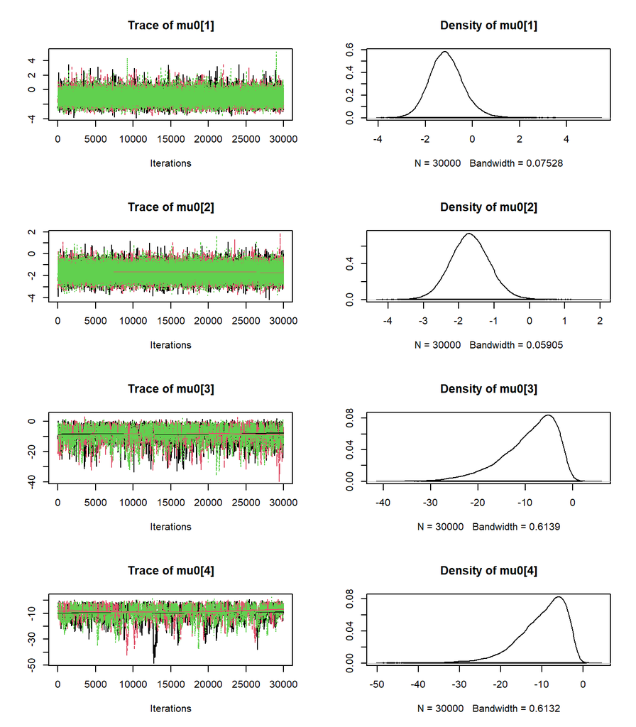

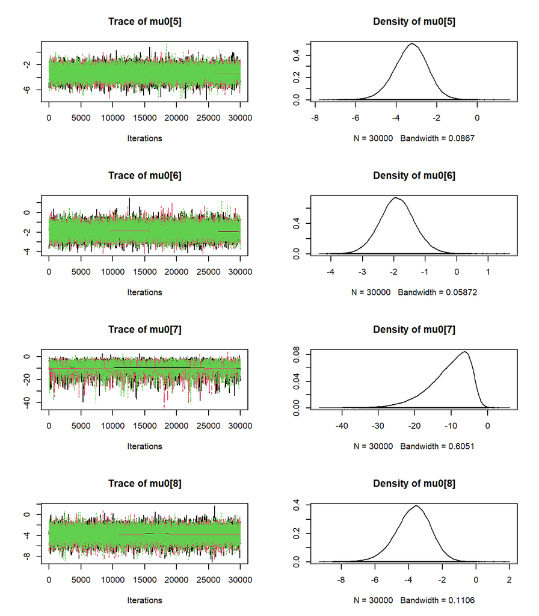

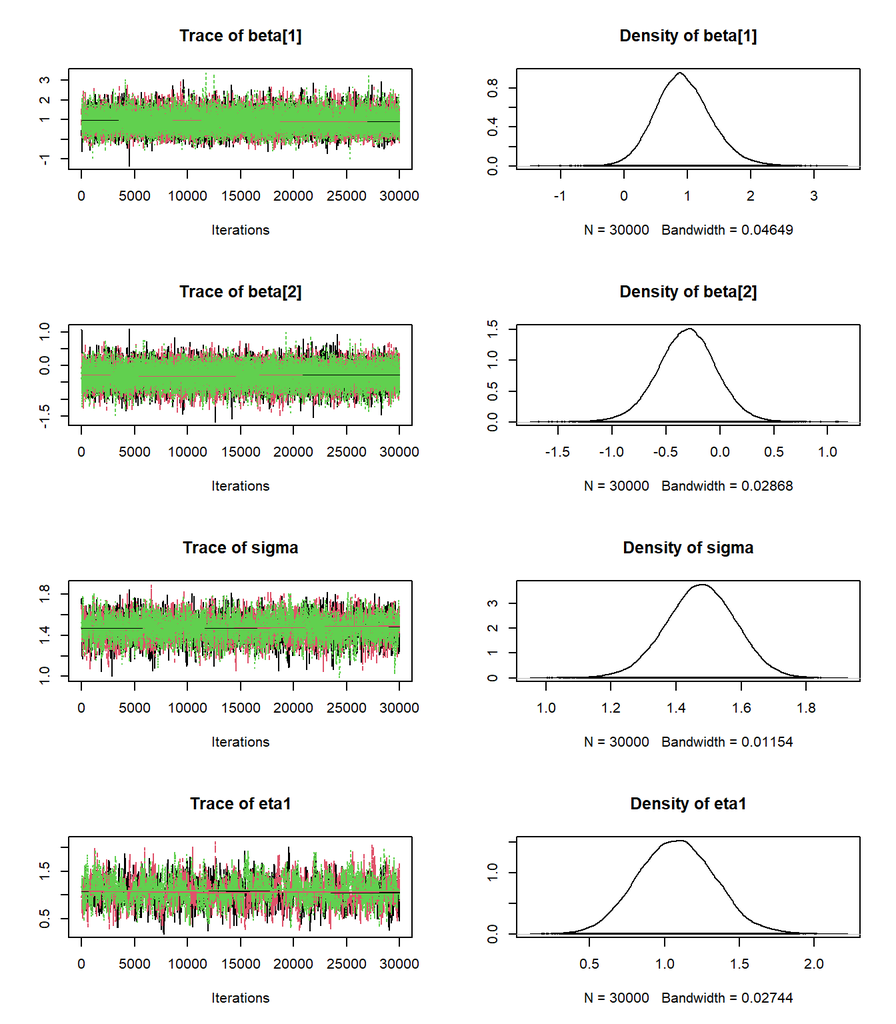

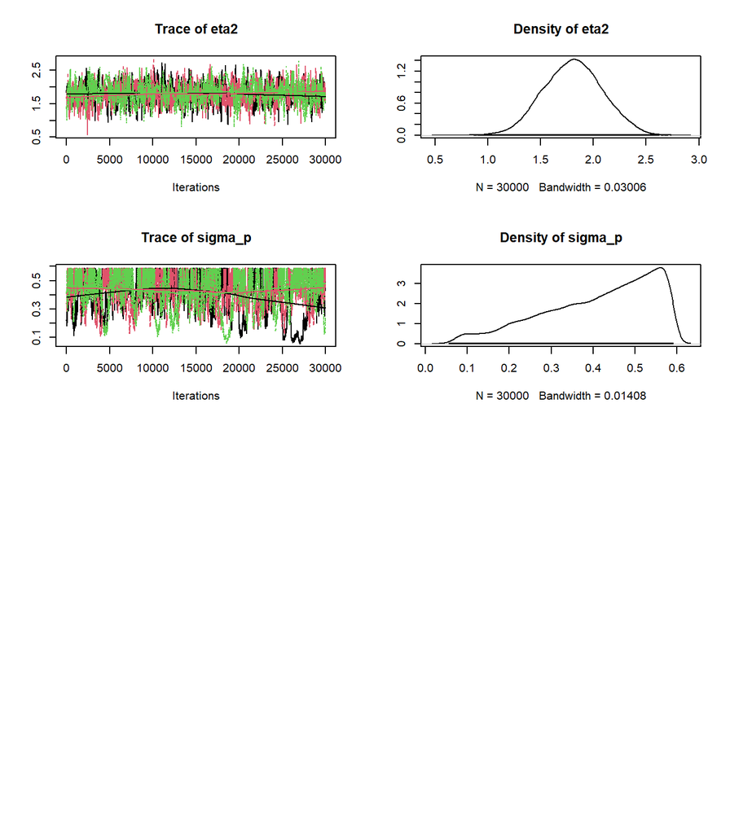

**Gelman and Rubin (1992) convergence diagnostics of `gamma_2` model:**

```
Potential scale reduction factors:

        Point est. Upper C.I.
mu0[1]        1.00       1.00
mu0[2]        1.00       1.00
mu0[3]        1.00       1.00
mu0[4]        1.01       1.02
mu0[5]        1.00       1.00
mu0[6]        1.00       1.00
mu0[7]        1.01       1.02
mu0[8]        1.00       1.00
beta[1]       1.00       1.00
beta[2]       1.00       1.00
sigma         1.00       1.00
eta1          1.01       1.05
eta2          1.02       1.06
sigma_p       1.05       1.15

Multivariate psrf

1.05
```

### 3.3.6 Posterior predictive checks

Posterior predictive checks with Bayesian p-values comparing simulated and observed values of $Y$ and $y$ (see Section 1 and Section 2.2) are presented in Figure 6.

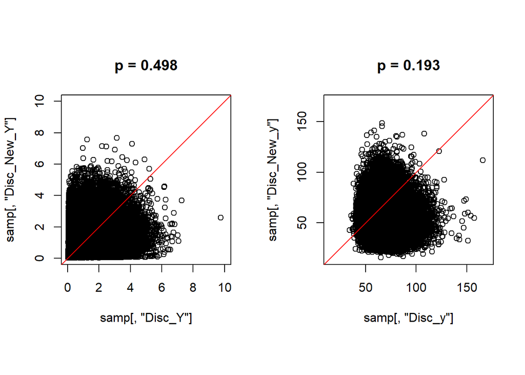

Figure 6: Posterior predictive checks for the `gamma2` model. Sum of the squared pearson residuals for simulated data (y-axis) are plotted against the sum of the squared pearson residuals for the original data (x-axis) for every posterior sample (open circles). The proportions of the points (open circles) that are above the 1-to-1 lines in red are the Bayesian p-values, printed above the plots. Left plot represents the total counts by the two observers ($Y$). Right plot represents the counts broken down to ‘seen by only observer 1’, ‘seen by only observer 2’ and ‘seen by both’ ($\mathbf{y}$).

### 3.3.7 Predictions from best model

#### 3.3.7.1 Deer density at the sample sites

While the main focus of the modelling was to estimate density where the sampled sites are assumed to be a random sample of a large number of sites of the same characteristics, we may also estimate deer density at the specific sites sampled (see Section 2.5). These estimates (posterior summaries) are presented in Table 3 from the `gamma0` model, and in Table 4 from the `gamma2` model.

Table 3: Summary for posterior distribution (`gamma0` model) for deer densities at the sampled sites at each sample area and month. Units are number of deer per hectare (1/100 km$^2$). The three rightmost columns show the 50%, the 2.5% and the 97.5% quantiles (in the three cases where no deer were observed (at Raa and at Sprakehaug in April) the mean is higher than the 97.5% quantile due to the low median and high variance of the posterior distribution).

| Sample area and month | Mean (deer/ha) | Median (deer/ha) | Lower 95% C.I. | Upper 95% C.I. |
| --- | --- | --- | --- | --- |
| Haugen (March) | 0.5184 | 0.4987 | 0.4987 | 0.6055 |
| Haugen (April) | 0.7909 | 0.7620 | 0.7620 | 0.8890 |
| Raa (March) | 0.0004 | 0.0000 | 0.0000 | 0.0000 |
| Raa (April) | 0.0008 | 0.0000 | 0.0000 | 0.0000 |
| Søre Bjørkum (March) | 0.3697 | 0.3699 | 0.3545 | 0.4162 |
| Søre Bjørkum (April) | 0.1783 | 0.1709 | 0.1709 | 0.2136 |
| Sprakehaug (March) | 0.1118 | 0.1073 | 0.1073 | 0.1609 |
| Sprakehaug (April) | 0.0004 | 0.0000 | 0.0000 | 0.0000 |

Table 4: Summary for posterior distribution (`gamma2` model) for deer densities at the sampled sites at each sample area and month. Units are number of deer per hectare (1/100 km$^2$). The three rightmost columns show the 50%, the 2.5% and the 97.5% quantiles (in the three cases where no deer were observed (at Raa and at Sprakehaug in April) the mean is higher than the 97.5% quantile due to the low median and high variance of the posterior distribution).

| Sample area and month | Mean (deer/ha) | Median (deer/ha) | Lower 95% C.I. | Upper 95% C.I. |
| --- | --- | --- | --- | --- |
| Haugen (March) | 0.5183 | 0.4987 | 0.4987 | 0.6055 |
| Haugen (April) | 0.7907 | 0.7620 | 0.7620 | 0.8890 |
| Raa (March) | 0.0004 | 0.0000 | 0.0000 | 0.0000 |
| Raa (April) | 0.0008 | 0.0000 | 0.0000 | 0.0000 |
| Søre Bjørkum (March) | 0.3702 | 0.3699 | 0.3545 | 0.4162 |
| Søre Bjørkum (April) | 0.1783 | 0.1709 | 0.1709 | 0.2136 |
| Sprakehaug (March) | 0.1119 | 0.1073 | 0.1073 | 0.1609 |
| Sprakehaug (April) | 0.0004 | 0.0000 | 0.0000 | 0.0000 |

#### 3.3.7.2 Density estimates

Estimated densities as a quadratic function of distance from the field (`gamma2` model) are shown in Figure 7, and estimates at the mean distance from the field are shown in Table 5. Table 6 shows the estimates from the `gamma0` model.

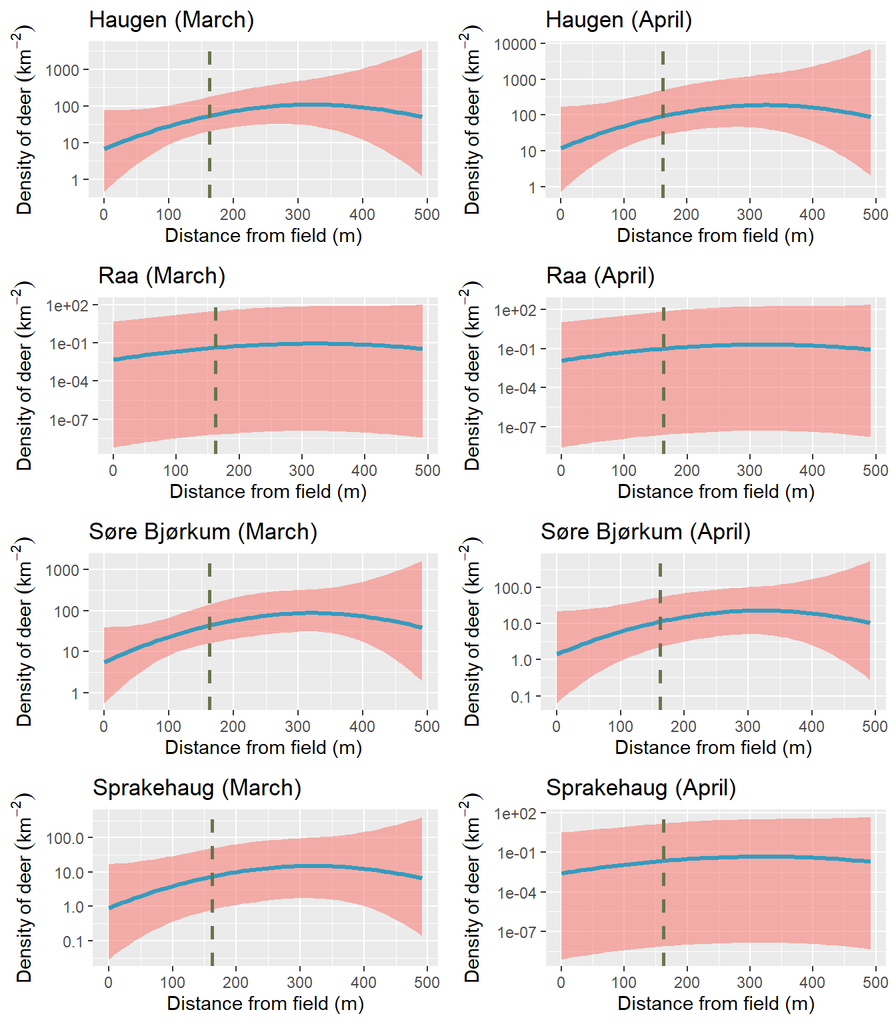

Figure 7: Plots of posterior summaries of deer density at the sampling areas (rows) and months (columns) as a quadratic function of distance from the field (`gamma2` model). Blue lines are the posterior medians, and the 95% credible intervals are shown with the shaded area. Stippled vertical lines are plotted at the overall mean distance from the field (162 meters). Note the widely different ranges on the y-axis (logarithmic scale).

Table 5: Summary for posterior distribution (`gamma2` model) for estimated deer densities at mean distance from the field (162 meters; stippled lines in Figure 7) at each of the sampling areas and months (when sites are considered to be a random sample of a large number of sites of the same characteristics). Units are number of deer per km$^2$.

| Sample area and month | Mean (deer/km$^2$) | Median (deer/km$^2$) | Lower 95% C.I. | Upper 95% C.I. |
| --- | --- | --- | --- | --- |
| Haugen (March) | 65.26 | 54.00 | 20.41 | 176.48 |
| Haugen (April) | 140.10 | 93.20 | 27.89 | 497.41 |
| Raa (March) | 3.66 | 0.04 | 0.00 | 31.65 |
| Raa (April) | 9.20 | 0.10 | 0.00 | 72.75 |
| Søre Bjørkum (March) | 52.76 | 43.63 | 16.26 | 143.46 |
| Søre Bjørkum (April) | 15.57 | 11.30 | 2.23 | 53.40 |
| Sprakehaug (March) | 12.02 | 7.41 | 0.81 | 49.22 |
| Sprakehaug (April) | 2.93 | 0.02 | 0.00 | 15.57 |

Table 6: Summary for posterior distribution (`gamma0` model) for estimated deer densities at each of the sampling areas and months (when sites are considered to be a random sample of a large number of sites of the same characteristics). Units are number of deer per km$^2$.

| Sample area and month | Mean (deer/km$^2$) | Median (deer/km$^2$) | Lower 95% C.I. | Upper 95% C.I. |
| --- | --- | --- | --- | --- |
| Haugen (March) | 65.81 | 54.00 | 20.10 | 178.82 |
| Haugen (April) | 162.10 | 98.51 | 29.19 | 559.85 |
| Raa (March) | 1.37 | 0.02 | 0.00 | 12.24 |
| Raa (April) | 3.31 | 0.04 | 0.00 | 28.07 |
| Søre Bjørkum (March) | 41.40 | 37.84 | 18.21 | 85.90 |
| Søre Bjørkum (April) | 24.04 | 18.14 | 4.20 | 78.61 |
| Sprakehaug (March) | 16.42 | 10.70 | 1.32 | 63.98 |
| Sprakehaug (April) | 2.70 | 0.03 | 0.00 | 18.53 |

#### 3.3.7.3 Process variation among sites

To interpret the parameter $\sigma$ (`sigma`) which describes the variation in deer densities ($\lambda$) among sites, we plot quantiles of the fitted gamma-distribution in Figure 8. Since the variance is high compared to the mean, the median of the distribution is close to zero.

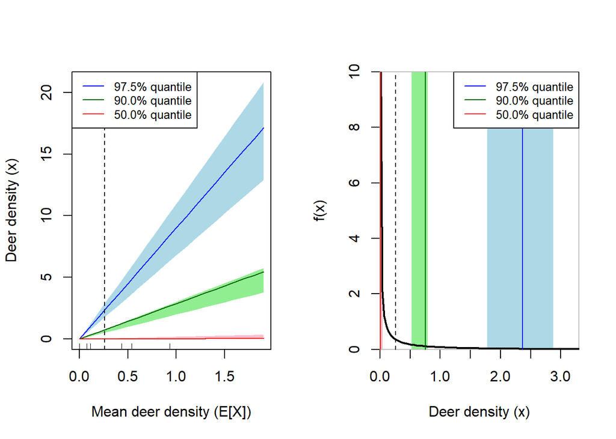

Figure 8: Summary of the process variation among sites. **Left:** Quantiles of the distribution of deer densities (ha$^{-1}$) among sites as a function of mean deer density. **Right:** The gamma distribution describing the variation in deer density among sites at the marginal mean deer density across sampling areas and months, indicated by the vertical stippled line in both panels (based on the posterior median of mean deer densities; second column of Table 5). The rug in the left plot shows the estimated mean densities (posterior medians) at the eight sampling area-months. Shaded areas show 95% credible intervals for the quantiles. Note that the median (in red) is close to zero (posterior median at 0.008).

### 3.3.8 Overlap with prior

Degrees of overlap between posterior and prior distributions for the parameters in the `gamma2` model are shown in Table 7. See Section 2 for prior justification. Note particularly that detection probability parameters `eta1`, `eta2` and `sigma_p` had priors informed by posterior detection probabilities from the enclosure data (see Section 3.2.3), and hence there are relatively high overlap between posterior and prior distributions for these parameters. Posterior distributions for the ‘mu’ parameters (see Section 1.2.3) where no deer has been observed, “Raa” and “Sprakehaug (April)” (see section Section 3.3.1), also have an overlap >0.4.

Table 7: Overlap between prior and posterior distributions for the parameters in the `gamma2` model (multiply by 100 to get %).

| Parameter | Sampling area and month | Prior distribution | Overlap |
| --- | --- | --- | --- |
| beta[1] |  | N(0, sd = 2) | 0.348 |
| beta[2] |  | N(0, sd = 2) | 0.260 |
| eta1 |  | N(1.4, sd = 0.36) | 0.583 |
| eta2 |  | N(1.4, sd = 0.36) | 0.519 |
| mu0[1] | Haugen (April) | N(0, sd = 10) | 0.158 |
| mu0[2] | Haugen (March) | N(0, sd = 10) | 0.124 |
| mu0[3] | Raa (April) | N(0, sd = 10) | 0.470 |
| mu0[4] | Raa (March) | N(0, sd = 10) | 0.439 |
| mu0[5] | Søre Bjørkum (April) | N(0, sd = 10) | 0.166 |
| mu0[6] | Søre Bjørkum (March) | N(0, sd = 10) | 0.123 |
| mu0[7] | Sprakehaug (April) | N(0, sd = 10) | 0.411 |
| mu0[8] | Sprakehaug (March) | N(0, sd = 10) | 0.200 |
| sigma |  | Gamma(shape = 0.01, rate = 0.01) | 0.006 |
| sigma_p |  | T[Gamma(shape = 1, rate = 0.05), 0, 0.59] | 0.696 |

### 3.3.9 Some sensitivity assessment

#### 3.3.9.1 Choice of random distribution for $\lambda$

To assess the sensitivity of the model predictions to the choice of random distribution of the Poisson expectation, $\lambda$, across sites, predictions from each of the nine candidate models at mean distance from field at Haugen in March are shown in Table 8. The exponential models give the most precise estimates, but have a substantially lower support by WAIC (Section 3.3.3). The log-normal models, which have marginally less support by WAIC than the gamma models, give substantially higher posterior mean and 97.5 percentile (upper 95% credible limit) than the gamma models (the posterior medians, and to a smaller degree the 2.5 percentile, are also somewhat higher). This is because the log-normal distribution has a heavier tail than the gamma-distribution with the same median and variance. The similarities in the WAIC values reflect that we have little information about the exact shape of the random distribution in the data (other than having evidence that the exponential distribution fits the data less well compared to the other two candidate distributions). In conclusion, we recognize that the upper 95% credible limits are highly model dependent, but have higher confidence in the lower 95% credible limits and the posterior medians.

Table 8: Posterior summaries for deer density (individuals per km$^2$) from each of the nine candidate models at mean distance from field at Haugen in March (WAIC values (Section 3.3.3) are given in the 2$^{\text{nd}}$ column)

| Model | WAIC | Mean (deer/km$^2$) | Median (deer/km$^2$) | Lower 95% C.I. | Upper 95% C.I. |
| --- | --- | --- | --- | --- | --- |
| exponential_0 | 122.84 | 53.06 | 50.91 | 26.96 | 91.47 |
| exponential_1 | 122.28 | 49.16 | 47.20 | 24.61 | 85.37 |
| exponential_2 | 121.48 | 49.44 | 47.43 | 24.57 | 85.91 |
| lognormal_0 | 113.68 | 151.46 | 81.22 | 23.81 | 561.65 |
| lognormal_1 | 113.64 | 174.19 | 73.54 | 21.45 | 512.14 |
| lognormal_2 | 113.79 | 165.16 | 76.92 | 21.83 | 597.10 |
| gamma_0 | 112.32 | 65.81 | 54.00 | 20.10 | 178.82 |
| gamma_1 | 112.40 | 63.06 | 52.41 | 19.92 | 168.83 |
| gamma_2 | 112.37 | 65.26 | 54.00 | 20.41 | 176.48 |

#### 3.3.9.2 Naive model without overdispersion

We did not consider a model without overdispersion as we did not think this would be biologically reasonable and simple preliminary analysis indicated that our data indeed was overdispersed relative to a Poisson distribution. However, since models without overdispersion (particularly for N-mixture models) are often used in the literature, we here also present results from a model without overdispersion and compare it with the WAIC-best model.

The summary from the model without overdispersion and a quadratic covariate effect is printed below. Although this model had significantly higher WAIC-value (128.09) than the models with overdispersion (see Table 8), the goodness-of-fit assessment based on Bayesian p-values did *not* indicate a significant lack of fit, Figure 9 (compare with Figure 6). Due to the overdispersion that has not been accounted for, credible intervals for parameters and predictions are too narrow (Table 9, Figure 10, and Table 10).

```
Iterations = 1:30000
Thinning interval = 1
Number of chains = 3
Sample size per chain = 30000

1. Empirical mean and standard deviation for each variable,
   plus standard error of the mean:

           Mean     SD  Naive SE Time-series SE
mu0[1]  -0.3652 0.2998 0.0009995      0.0011026
mu0[2]  -0.8013 0.2776 0.0009254      0.0010471
mu0[3]  -8.9120 5.8814 0.0196047      0.0226892
mu0[4]  -9.3593 5.7117 0.0190389      0.0219851
mu0[5]  -2.1491 0.5506 0.0018352      0.0020979
mu0[6]  -0.9676 0.2619 0.0008730      0.0012100
mu0[7]  -9.8882 5.6420 0.0188065      0.0221495
mu0[8]  -2.6774 0.8106 0.0027020      0.0030646
beta[1]  0.6556 0.2288 0.0007628      0.0014509
beta[2] -0.2051 0.1291 0.0004302      0.0008436
eta1     1.0769 0.2596 0.0008655      0.0101998
eta2     1.8070 0.2685 0.0008949      0.0101699
sigma_p  0.3857 0.1463 0.0004875      0.0101565

2. Quantiles for each variable:

            2.5%      25%     50%     75%    97.5%
mu0[1]   -0.9940  -0.5568 -0.3522 -0.1568  0.18081
mu0[2]   -1.3789  -0.9812 -0.7890 -0.6090 -0.29271
mu0[3]  -23.0803 -12.2754 -7.7351 -4.3628 -1.12243
mu0[4]  -23.0794 -12.6446 -8.1931 -4.9342 -1.76938
mu0[5]   -3.3405  -2.4891 -2.1101 -1.7650 -1.18593
mu0[6]   -1.5030  -1.1399 -0.9575 -0.7860 -0.48105
mu0[7]  -23.5134 -13.0394 -8.6767 -5.5708 -2.49515
mu0[8]   -4.5123  -3.1506 -2.5889 -2.1091 -1.34588
beta[1]   0.2313   0.4973  0.6466  0.8048  1.12763
beta[2]  -0.4724  -0.2883 -0.2002 -0.1163  0.03412
eta1      0.5944   0.8957  1.0669  1.2483  1.61238
eta2      1.2803   1.6283  1.8036  1.9855  2.33699
sigma_p   0.1046   0.2643  0.4144  0.5132  0.58313
```

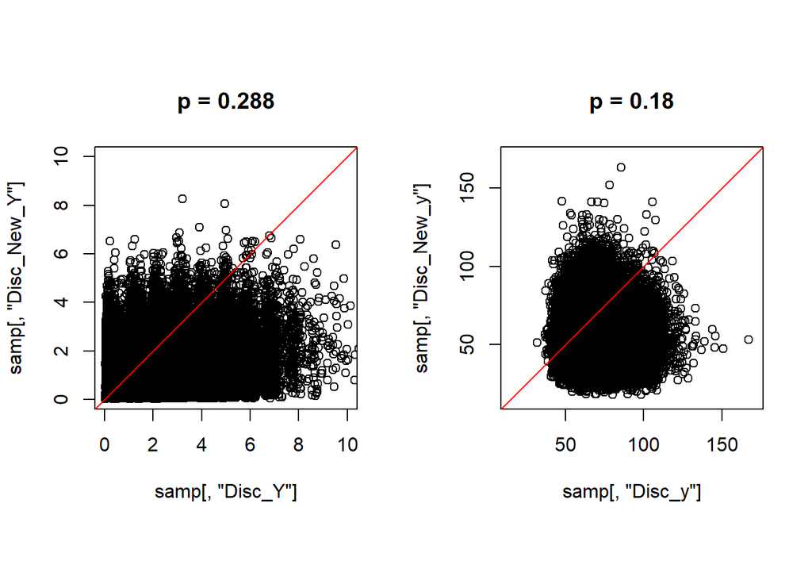

Figure 9: Posterior predictive checks for the naive model without overdisperson. Left plot represents the total counts by the two observers ($Y$). Right plot represents the counts broken down to ‘seen by only observer 1’, ‘seen by only observer 2’ and ‘seen by both’ ($\mathbf{y}$). Bayesian p-values are printed above the plots. Compare with Figure 6.

Table 9: Summary for posterior distribution for deer densities at the sampled sites at each sample area and month when overdispersion has been ignored. Compare with Table 4.

| Sample area and month | Mean (deer/ha) | Median (deer/ha) | Lower 95% C.I. | Upper 95% C.I. |
| --- | --- | --- | --- | --- |
| Haugen (March) | 0.5192 | 0.4987 | 0.4987 | 0.6055 |
| Haugen (April) | 0.7933 | 0.7620 | 0.7620 | 0.8890 |
| Raa (March) | 0.0003 | 0.0000 | 0.0000 | 0.0000 |
| Raa (April) | 0.0007 | 0.0000 | 0.0000 | 0.0000 |
| Søre Bjørkum (March) | 0.3693 | 0.3699 | 0.3545 | 0.4162 |
| Søre Bjørkum (April) | 0.1781 | 0.1709 | 0.1709 | 0.2136 |
| Sprakehaug (March) | 0.1117 | 0.1073 | 0.1073 | 0.1609 |
| Sprakehaug (April) | 0.0004 | 0.0000 | 0.0000 | 0.0000 |

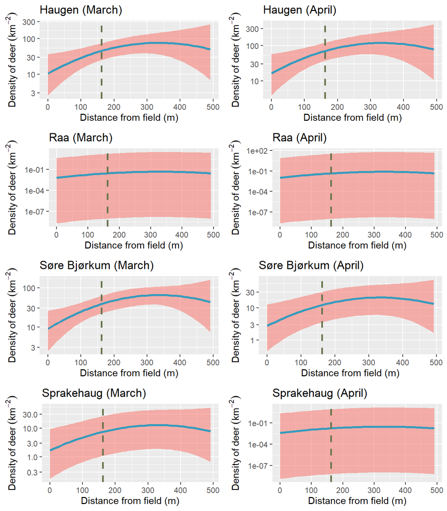

Figure 10: Plots of posterior summaries of deer density at the sampling areas (rows) and months (columns) as a quadratic function of distance from the field when overdispersion is not accounted for. Compare with Figure 7.

Table 10: Summary for posterior distribution for estimated deer densities at mean distance from the field when overdispersion has not been accounted for. Compare with Table 5.

| Sample area and month | Mean (deer/km$^2$) | Median (deer/km$^2$) | Lower 95% C.I. | Upper 95% C.I. |
| --- | --- | --- | --- | --- |
| Haugen (March) | 46.59 | 45.43 | 25.19 | 74.62 |
| Haugen (April) | 72.51 | 70.31 | 37.01 | 119.82 |
| Raa (March) | 1.80 | 0.03 | 0.00 | 17.04 |
| Raa (April) | 3.41 | 0.04 | 0.00 | 32.55 |
| Søre Bjørkum (March) | 39.30 | 38.38 | 22.25 | 61.81 |
| Søre Bjørkum (April) | 13.41 | 12.12 | 3.54 | 30.55 |
| Sprakehaug (March) | 9.08 | 7.51 | 1.10 | 26.03 |
| Sprakehaug (April) | 0.88 | 0.02 | 0.00 | 8.25 |

#### 3.3.9.3 Sensitivity to prior for $\sigma_p$

We used a somewhat informative prior for $\sigma_p$ (`sigma_p`) (Section 2.2 and Section 3.3.8). To assess the sensitivity of the model results to this prior, we also fitted a model with a $\text{Uniform}(0, 10)$ prior for $\sigma_p$. The summary of this model is shown below and posterior summaries from this model are compared to the summaries from the original model in Figure 11.

Despite the substantially higher posterior values for $\sigma_p$ with the wider prior, the posterior distributions for other parameters are little affected (Figure 11). There are no strong correlations between posterior samples of the the parameters for neither the original model (Table 11) nor the model with the wider prior for $\sigma_p$ (Table 12). We conclude that our results are not sensitive to the choice of prior for $\sigma_p$.

```
Iterations = 1:30000
Thinning interval = 1
Number of chains = 3
Sample size per chain = 30000

1. Empirical mean and standard deviation for each variable,
   plus standard error of the mean:

            Mean     SD  Naive SE Time-series SE
mu0[1]   -1.0752 0.7193 0.0023975       0.003165
mu0[2]   -1.6304 0.5546 0.0018486       0.003355
mu0[3]   -9.3395 5.7063 0.0190211       0.174803
mu0[4]   -9.4139 5.2895 0.0176318       0.189126
mu0[5]   -3.1941 0.8153 0.0027176       0.005469
mu0[6]   -1.8422 0.5553 0.0018510       0.004445
mu0[7]  -10.2834 5.5520 0.0185066       0.141999
mu0[8]   -3.6850 1.0454 0.0034848       0.007307
beta[1]   0.9313 0.4406 0.0014685       0.004492
beta[2]  -0.2988 0.2738 0.0009127       0.002858
sigma     1.4603 0.1083 0.0003611       0.002109
eta1      1.3498 0.3235 0.0010783       0.003534
eta2      1.7470 0.3334 0.0011112       0.003486
sigma_p   2.8149 1.4725 0.0049083       0.113930

2. Quantiles for each variable:

            2.5%      25%     50%     75%   97.5%
mu0[1]   -2.3994  -1.5552 -1.1077 -0.6339  0.4513
mu0[2]   -2.7124  -1.9991 -1.6345 -1.2706 -0.5166
mu0[3]  -22.4682 -12.7631 -8.3043 -4.9496 -1.3547
mu0[4]  -22.2840 -12.3709 -8.3578 -5.4134 -2.1778
mu0[5]   -4.8709  -3.7195 -3.1704 -2.6449 -1.6685
mu0[6]   -2.9164  -2.2108 -1.8455 -1.4797 -0.7379
mu0[7]  -23.8318 -13.3143 -9.1482 -6.1587 -2.8319
mu0[8]   -5.9109  -4.3375 -3.6297 -2.9737 -1.7799
beta[1]   0.1226   0.6309  0.9093  1.2109  1.8554
beta[2]  -0.8511  -0.4758 -0.2944 -0.1170  0.2296
sigma     1.2386   1.3897  1.4632  1.5342  1.6641
eta1      0.7303   1.1286  1.3454  1.5671  1.9944
eta2      1.0858   1.5244  1.7497  1.9717  2.3952
sigma_p   0.9534   1.7604  2.4686  3.5025  6.7068
```

```
Iterations = 1:30000
Thinning interval = 1
Number of chains = 3
Sample size per chain = 30000

1. Empirical mean and standard deviation for each variable,
   plus standard error of the mean:

            Mean     SD  Naive SE Time-series SE
mu0[1]   -1.1061 0.7304 0.0024348       0.003038
mu0[2]   -1.6833 0.5553 0.0018511       0.002872
mu0[3]   -9.2050 5.7448 0.0191493       0.174775
mu0[4]  -10.0699 5.9788 0.0199295       0.236475
mu0[5]   -3.2834 0.8169 0.0027228       0.005289
mu0[6]   -1.8971 0.5569 0.0018562       0.004096
mu0[7]  -10.6245 5.7033 0.0190109       0.143465
mu0[8]   -3.7387 1.0505 0.0035017       0.007095
beta[1]   0.9325 0.4398 0.0014659       0.004414
beta[2]  -0.3060 0.2721 0.0009070       0.002708
sigma     1.4750 0.1066 0.0003553       0.002001
eta1      1.0791 0.2535 0.0008450       0.008405
eta2      1.8080 0.2777 0.0009256       0.010057
sigma_p   0.4150 0.1301 0.0004335       0.007140

2. Quantiles for each variable:

            2.5%      25%     50%     75%   97.5%
mu0[1]   -2.4443  -1.5935 -1.1409 -0.6618  0.4391
mu0[2]   -2.7556  -2.0530 -1.6912 -1.3221 -0.5722
mu0[3]  -23.2634 -12.4514 -8.0056 -4.8528 -1.4291
mu0[4]  -24.6458 -13.2354 -8.8568 -5.6456 -2.2541
mu0[5]   -4.9505  -3.8089 -3.2604 -2.7358 -1.7333
mu0[6]   -2.9858  -2.2629 -1.9033 -1.5360 -0.7846
mu0[7]  -24.3959 -13.7919 -9.4837 -6.3022 -2.9712
mu0[8]   -5.9523  -4.3948 -3.6837 -3.0257 -1.8186
beta[1]   0.1197   0.6340  0.9107  1.2095  1.8577
beta[2]  -0.8527  -0.4819 -0.3023 -0.1269  0.2228
sigma     1.2614   1.4048  1.4767  1.5478  1.6780
eta1      0.5942   0.9038  1.0773  1.2508  1.5841
eta2      1.2701   1.6169  1.8092  1.9975  2.3513
sigma_p   0.1196   0.3243  0.4420  0.5249  0.5844
```

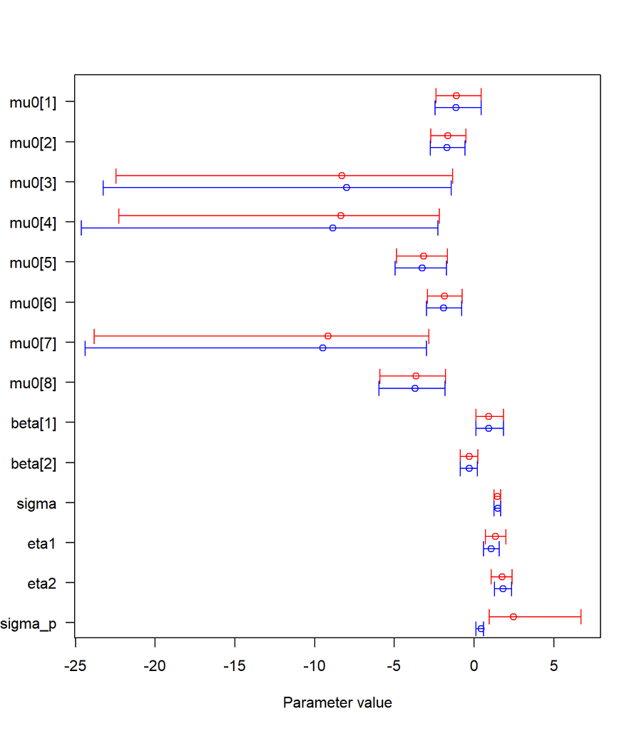

Figure 11: Posterior medians and 95% credible intervals for the parameters in `gamma2` model; orignal model in blue and model with wider $\text{Uniform}(0, 10)$ prior for $\sigma_p$ (`sigma_p`) in red. The lower credible bounds for $\mu_0$ where no deer has been seen (`mu0[3]`, `mu0[4]`, and `mu0[7]`) are naturally sensitive to priors as it impossible to tell how close to zero the densities may be - on the arithmetic scale, the density estimates for these area-months are essentially zero.

Table 11: Correlation matrix for posterior samples in the original ‘gamma2’ model.

|  | mu0[1] | mu0[2] | mu0[3] | mu0[4] | mu0[5] | mu0[6] | mu0[7] | mu0[8] | beta[1] | beta[2] | sigma | eta1 | eta2 | sigma_p |
| --- | --- | --- | --- | --- | --- | --- | --- | --- | --- | --- | --- | --- | --- | --- |
| mu0[1] | 1.000 | 0.019 | -0.002 | 0.001 | 0.032 | 0.050 | 0.003 | 0.022 | 0.005 | -0.041 | -0.099 | -0.005 | -0.013 | 0.000 |
| mu0[2] | 0.019 | 1.000 | 0.001 | -0.002 | 0.047 | 0.069 | 0.001 | 0.030 | 0.017 | -0.047 | -0.196 | -0.012 | -0.015 | 0.000 |
| mu0[3] | -0.002 | 0.001 | 1.000 | -0.005 | -0.009 | 0.016 | -0.022 | -0.006 | 0.033 | -0.029 | -0.015 | -0.016 | -0.014 | -0.035 |
| mu0[4] | 0.001 | -0.002 | -0.005 | 1.000 | -0.006 | 0.012 | 0.013 | -0.002 | 0.043 | -0.039 | 0.016 | 0.004 | -0.008 | 0.035 |
| mu0[5] | 0.032 | 0.047 | -0.009 | -0.006 | 1.000 | 0.156 | 0.022 | 0.131 | -0.226 | -0.079 | -0.172 | -0.011 | -0.019 | -0.002 |
| mu0[6] | 0.050 | 0.069 | 0.016 | 0.012 | 0.156 | 1.000 | 0.008 | 0.127 | 0.203 | -0.546 | -0.182 | -0.024 | -0.020 | -0.002 |
| mu0[7] | 0.003 | 0.001 | -0.022 | 0.013 | 0.022 | 0.008 | 1.000 | -0.001 | -0.019 | -0.004 | 0.001 | -0.045 | 0.040 | 0.008 |
| mu0[8] | 0.022 | 0.030 | -0.006 | -0.002 | 0.131 | 0.127 | -0.001 | 1.000 | -0.150 | -0.080 | -0.124 | -0.005 | -0.017 | -0.003 |
| beta[1] | 0.005 | 0.017 | 0.033 | 0.043 | -0.226 | 0.203 | -0.019 | -0.150 | 1.000 | -0.676 | 0.081 | -0.006 | 0.015 | -0.008 |
| beta[2] | -0.041 | -0.047 | -0.029 | -0.039 | -0.079 | -0.546 | -0.004 | -0.080 | -0.676 | 1.000 | -0.025 | 0.009 | -0.006 | 0.009 |
| sigma | -0.099 | -0.196 | -0.015 | 0.016 | -0.172 | -0.182 | 0.001 | -0.124 | 0.081 | -0.025 | 1.000 | 0.007 | 0.012 | 0.018 |
| eta1 | -0.005 | -0.012 | -0.016 | 0.004 | -0.011 | -0.024 | -0.045 | -0.005 | -0.006 | 0.009 | 0.007 | 1.000 | 0.024 | 0.064 |
| eta2 | -0.013 | -0.015 | -0.014 | -0.008 | -0.019 | -0.020 | 0.040 | -0.017 | 0.015 | -0.006 | 0.012 | 0.024 | 1.000 | -0.047 |
| sigma_p | 0.000 | 0.000 | -0.035 | 0.035 | -0.002 | -0.002 | 0.008 | -0.003 | -0.008 | 0.009 | 0.018 | 0.064 | -0.047 | 1.000 |

Table 12: Correlation matrix for posterior samples in the ‘gamma2’ mode with wider $\text{Uniform}(0, 10)$ prior for $\sigma_p$ (`sigma_p`)

|  | mu0[1] | mu0[2] | mu0[3] | mu0[4] | mu0[5] | mu0[6] | mu0[7] | mu0[8] | beta[1] | beta[2] | sigma | eta1 | eta2 | sigma_p |
| --- | --- | --- | --- | --- | --- | --- | --- | --- | --- | --- | --- | --- | --- | --- |
| mu0[1] | 1.000 | 0.031 | -0.005 | 0.004 | 0.035 | 0.052 | 0.001 | 0.031 | -0.012 | -0.033 | -0.113 | -0.004 | -0.027 | 0.047 |
| mu0[2] | 0.031 | 1.000 | 0.003 | 0.001 | 0.047 | 0.079 | 0.001 | 0.035 | 0.020 | -0.052 | -0.208 | -0.006 | -0.037 | 0.083 |
| mu0[3] | -0.005 | 0.003 | 1.000 | -0.034 | -0.007 | 0.019 | 0.006 | 0.001 | 0.038 | -0.033 | -0.015 | 0.001 | 0.005 | 0.012 |
| mu0[4] | 0.004 | 0.001 | -0.034 | 1.000 | -0.015 | 0.027 | 0.013 | -0.018 | 0.062 | -0.059 | -0.003 | 0.025 | -0.002 | 0.026 |
| mu0[5] | 0.035 | 0.047 | -0.007 | -0.015 | 1.000 | 0.149 | 0.010 | 0.124 | -0.226 | -0.069 | -0.172 | -0.015 | -0.028 | 0.053 |
| mu0[6] | 0.052 | 0.079 | 0.019 | 0.027 | 0.149 | 1.000 | 0.018 | 0.117 | 0.213 | -0.543 | -0.201 | -0.014 | -0.035 | 0.091 |
| mu0[7] | 0.001 | 0.001 | 0.006 | 0.013 | 0.010 | 0.018 | 1.000 | 0.018 | -0.023 | -0.008 | -0.004 | -0.005 | -0.003 | -0.011 |
| mu0[8] | 0.031 | 0.035 | 0.001 | -0.018 | 0.124 | 0.117 | 0.018 | 1.000 | -0.148 | -0.069 | -0.145 | -0.007 | -0.034 | 0.043 |
| beta[1] | -0.012 | 0.020 | 0.038 | 0.062 | -0.226 | 0.213 | -0.023 | -0.148 | 1.000 | -0.685 | 0.075 | 0.000 | 0.007 | 0.004 |
| beta[2] | -0.033 | -0.052 | -0.033 | -0.059 | -0.069 | -0.543 | -0.008 | -0.069 | -0.685 | 1.000 | -0.021 | 0.007 | -0.007 | -0.003 |
| sigma | -0.113 | -0.208 | -0.015 | -0.003 | -0.172 | -0.201 | -0.004 | -0.145 | 0.075 | -0.021 | 1.000 | 0.014 | 0.050 | -0.116 |
| eta1 | -0.004 | -0.006 | 0.001 | 0.025 | -0.015 | -0.014 | -0.005 | -0.007 | 0.000 | 0.007 | 0.014 | 1.000 | 0.013 | 0.162 |
| eta2 | -0.027 | -0.037 | 0.005 | -0.002 | -0.028 | -0.035 | -0.003 | -0.034 | 0.007 | -0.007 | 0.050 | 0.013 | 1.000 | -0.190 |
| sigma_p | 0.047 | 0.083 | 0.012 | 0.026 | 0.053 | 0.091 | -0.011 | 0.043 | 0.004 | -0.003 | -0.116 | 0.162 | -0.190 | 1.000 |

### 3.3.10 Proof of concept - Identifiability assessment by simulations

#### 3.3.10.1 Boosting sample size

Posterior summaries from the model fitted to the boosted data are shown below, overlap between prior and posterior distributions are shown in Table 13, predicted densities are plotted in Figure 12, and predicted densities at mean distance from the field are shown in Table 14.

With this much data (8 areas with 500 sites each), we obtain substantially higher precision of the estimates, as well as lower overlap between posterior and prior distributions. This shows that that there are no inherent identifiability problems in the model. One would perhaps expect higher precision (narrower credible intervals) when having 8 $\times$ 500 sites, but the high variation in number of deer per sites contributes to much uncertainty, and since the average area of sites is just under 0.6 ha (0.6% of a km$^2$), the expected counts per site is quite small. In the next simulation, we also reduced the random variation among sites within areas.

```
Iterations = 1:30000
Thinning interval = 1
Number of chains = 3
Sample size per chain = 30000

1. Empirical mean and standard deviation for each variable,
   plus standard error of the mean:

            Mean      SD  Naive SE Time-series SE
beta[1]   0.8995 0.10428 0.0003476      0.0009246
beta[2]  -0.2924 0.07542 0.0002514      0.0007335
eta1      0.9857 0.10396 0.0003465      0.0071195
eta2      1.7378 0.12180 0.0004060      0.0096278
mu0[1]   -1.1607 0.16759 0.0005586      0.0012902
mu0[2]   -1.6801 0.17255 0.0005752      0.0013398
mu0[3]   -7.1290 1.20691 0.0040230      0.0385446
mu0[4]  -12.8709 5.00279 0.0166760      0.6756462
mu0[5]   -3.2925 0.24855 0.0008285      0.0017874
mu0[6]   -1.6387 0.17670 0.0005890      0.0012403
mu0[7]  -13.0874 5.21458 0.0173819      0.7356025
mu0[8]   -4.6047 0.39887 0.0013296      0.0041903
sigma     1.4497 0.03246 0.0001082      0.0006676
sigma_p   0.3354 0.15154 0.0005051      0.0188382

2. Quantiles for each variable:

             2.5%      25%      50%     75%   97.5%
beta[1]   0.69761   0.8285   0.8983  0.9705  1.1054
beta[2]  -0.43831  -0.3435  -0.2930 -0.2418 -0.1431
eta1      0.79104   0.9115   0.9848  1.0558  1.1953
eta2      1.51099   1.6499   1.7371  1.8246  1.9718
mu0[1]   -1.48827  -1.2731  -1.1612 -1.0476 -0.8329
mu0[2]   -2.01966  -1.7967  -1.6791 -1.5639 -1.3436
mu0[3]   -9.99584  -7.7731  -6.9418 -6.2783 -5.3060
mu0[4]  -25.56872 -15.4319 -11.7917 -9.1060 -6.4719
mu0[5]   -3.78775  -3.4578  -3.2898 -3.1240 -2.8168
mu0[6]   -1.98488  -1.7576  -1.6392 -1.5192 -1.2908
mu0[7]  -26.77264 -15.6869 -11.8302 -9.1332 -6.5592
mu0[8]   -5.43604  -4.8623  -4.5871 -4.3278 -3.8701
sigma     1.38511   1.4282   1.4499  1.4714  1.5132
sigma_p   0.07493   0.2129   0.3384  0.4721  0.5771
```

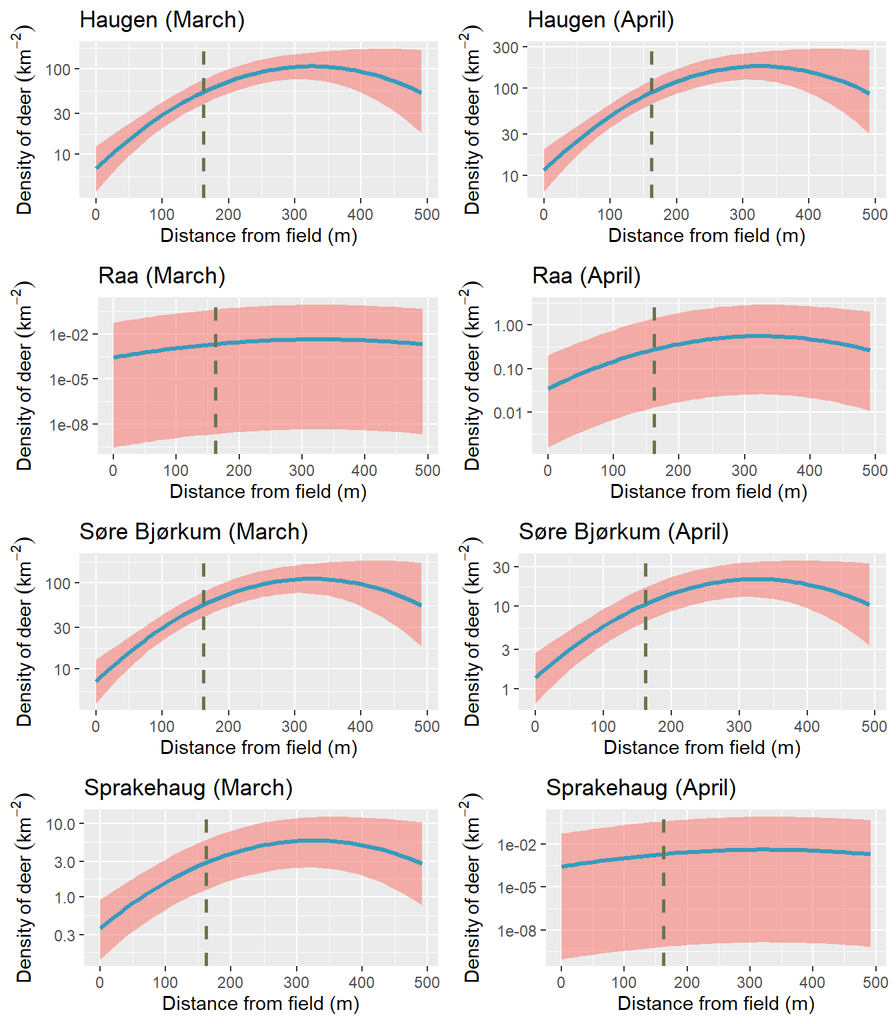

Figure 12: Simulation results: Plots of posterior summaries of deer density when sample size has increased to 500 sites per area and month, with model parameters set to posterior median of original fit. Compare with Figure 7.

Table 13: Simulation results: Overlap between prior and posterior distributions for the parameters when sample size has been increased to 500 sites per study area and month. Compare with Table 7.

| Parameter | Sampling area and month | Prior distribution | Overlap |
| --- | --- | --- | --- |
| beta[1] |  | N(0, sd = 2) | 0.106 |
| beta[2] |  | N(0, sd = 2) | 0.087 |
| eta1 |  | N(1.4, sd = 0.36) | 0.275 |
| eta2 |  | N(1.4, sd = 0.36) | 0.363 |
| mu0[1] | Haugen (April) | N(0, sd = 10) | 0.043 |
| mu0[2] | Haugen (March) | N(0, sd = 10) | 0.043 |
| mu0[3] | Raa (April) | N(0, sd = 10) | 0.182 |
| mu0[4] | Raa (March) | N(0, sd = 10) | 0.286 |
| mu0[5] | Søre Bjørkum (April) | N(0, sd = 10) | 0.058 |
| mu0[6] | Søre Bjørkum (March) | N(0, sd = 10) | 0.044 |
| mu0[7] | Sprakehaug (April) | N(0, sd = 10) | 0.282 |
| mu0[8] | Sprakehaug (March) | N(0, sd = 10) | 0.084 |
| sigma |  | Gamma(shape = 0.01, rate = 0.01) | 0.002 |
| sigma_p |  | T[Gamma(shape = 1, rate = 0.05), 0, 0.59] | 0.867 |

Table 14: Simulation results: Summary for posterior distribution for estimated deer densities at mean distance from the field (162 meters; stippled lines in Figure 12) when sample size has been increased to 500 sites per area and moth. Compare with Table 5.

| Sample area and month | Mean (deer/km$^2$) | Median (deer/km$^2$) | Lower 95% C.I. | Upper 95% C.I. |
| --- | --- | --- | --- | --- |
| Haugen (March) | 54.06 | 53.31 | 38.67 | 73.97 |
| Haugen (April) | 90.82 | 89.50 | 65.75 | 123.53 |
| Raa (March) | 0.05 | 0.00 | 0.00 | 0.45 |
| Raa (April) | 0.39 | 0.28 | 0.01 | 1.42 |
| Søre Bjørkum (March) | 56.41 | 55.45 | 39.89 | 78.22 |
| Søre Bjørkum (April) | 10.95 | 10.66 | 6.54 | 17.00 |
| Sprakehaug (March) | 3.09 | 2.91 | 1.25 | 5.95 |
| Sprakehaug (April) | 0.05 | 0.00 | 0.00 | 0.41 |

#### 3.3.10.2 Boosting sample size and reducing $\sigma$

To investigate the impact of variation in density within sampling areas, we reduced $\sigma$ to 5% of the estimated value while keeping the mean densities the same. This entails changing $\sigma$ to $\sigma'=\alpha\sigma$ and $\mu_{0,j}$ to $\mu_{0,j}'= \mu_{0,j} + \sigma^2(1-\alpha^2)/2$ where $\alpha = 0.05$. The resulting variation in density among sites is shown in Figure 13.

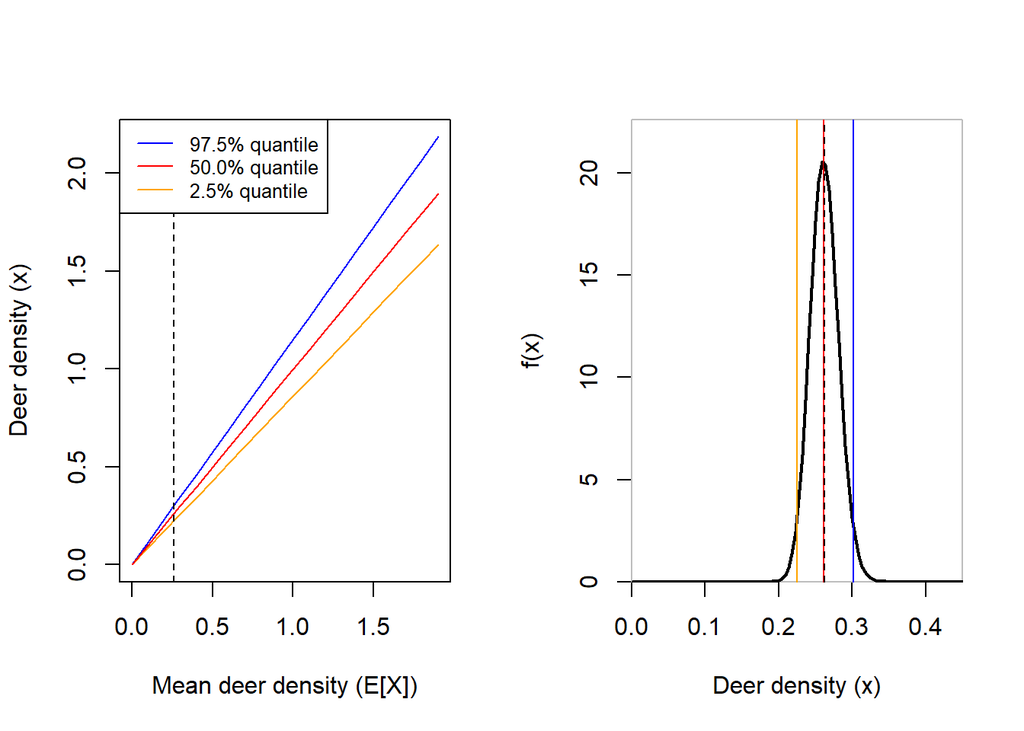

Figure 13: Summary of the process variation among sites in the simulation where $\sigma$ has been reduced to 5% of the estimated value while keeping the mean densities the same. **Left:** Quantiles of the distribution of deer densities (ha$^{-1}$) among sites as a function of mean deer density. **Right:** The gamma distribution describing the variation in deer density among sites at the marginal mean deer density across sampling areas and months, indicated by the vertical stippled line in both panels (based on the posterior median of mean deer densities; second column of Table 5). Compare with the estimated distribution shown in Figure 8

Posterior summaries from the model fitted the simulated data are shown below, overlap between prior and posterior distributions are shown in Table 15, predicted densities are plotted in Figure 14, and predicted densities at mean distance from the field are shown in Table 16.

```
Iterations = 1:30000
Thinning interval = 1
Number of chains = 3
Sample size per chain = 30000

1. Empirical mean and standard deviation for each variable,
   plus standard error of the mean:

            Mean      SD  Naive SE Time-series SE
beta[1]  1.08400 0.07952 0.0002651       0.012521
beta[2] -0.41645 0.05512 0.0001837       0.012074
eta1     1.06999 0.09161 0.0003054       0.004536
eta2     1.84020 0.11817 0.0003939       0.007088
mu0[1]  -0.03231 0.06629 0.0002210       0.008476
mu0[2]  -0.61594 0.07560 0.0002520       0.009180
mu0[3]  -7.04693 1.84428 0.0061476       0.072798
mu0[4]  -7.89821 1.00514 0.0033505       0.092203
mu0[5]  -2.18414 0.16818 0.0005606       0.018155
mu0[6]  -0.65359 0.07894 0.0002631       0.009018
mu0[7]  -7.20157 1.27744 0.0042581       0.120449
mu0[8]  -2.68511 0.21937 0.0007312       0.015500
sigma    0.04003 0.04843 0.0001614       0.008764
sigma_p  0.37152 0.13475 0.0004492       0.023799

2. Quantiles for each variable:

              2.5%       25%      50%      75%    97.5%
beta[1]   0.913492  1.008271  1.11365  1.14087  1.21291
beta[2]  -0.514581 -0.444248 -0.43159 -0.37142 -0.31456
eta1      0.890593  1.007851  1.06926  1.13148  1.25187
eta2      1.615310  1.758540  1.83732  1.91603  2.08174
mu0[1]   -0.167719 -0.078850 -0.03162  0.01811  0.08219
mu0[2]   -0.769082 -0.657829 -0.61693 -0.58667 -0.43182
mu0[3]  -10.196259 -9.329650 -6.33193 -5.30688 -4.92005
mu0[4]   -9.230805 -8.992867 -7.86135 -7.05486 -6.28998
mu0[5]   -2.431293 -2.355133 -2.14915 -2.07305 -1.92029
mu0[6]   -0.799318 -0.701028 -0.66041 -0.61560 -0.48165
mu0[7]   -9.238339 -8.388753 -7.35461 -5.96905 -4.63586
mu0[8]   -3.094282 -2.890581 -2.60810 -2.55403 -2.26910
sigma     0.002172  0.006771  0.01813  0.06216  0.17384
sigma_p   0.114691  0.259565  0.38750  0.48131  0.57872
```

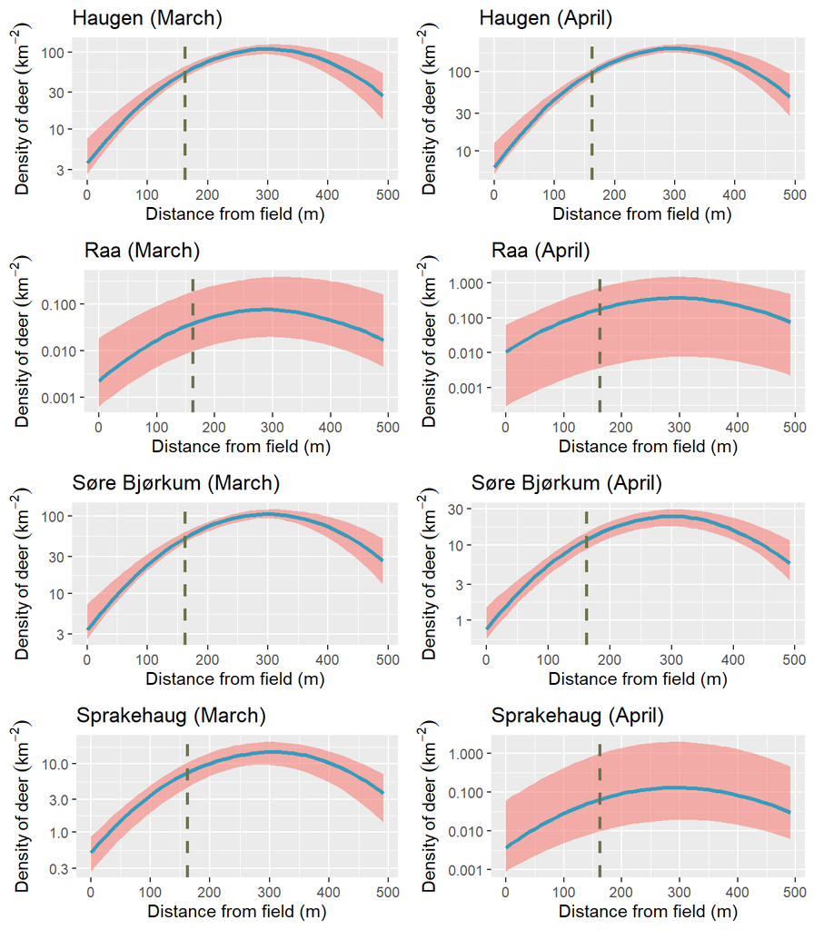

Figure 14: Simulation results from the scenario where among site variation has been reduced: Plots of posterior summaries of deer density. Compare with Figure 7 for the model fitted to the observed data.

Table 15: Simulation results from the scenario where among site variation has been reduced:: Overlap between prior and posterior distributions for the parameters. Compare with Table 7 for the model fitted to the observed data.

| Parameter | Sampling area and month | Prior distribution | Overlap |
| --- | --- | --- | --- |
| beta[1] |  | N(0, sd = 2) | 0.067 |
| beta[2] |  | N(0, sd = 2) | 0.046 |
| eta1 |  | N(1.4, sd = 0.36) | 0.302 |
| eta2 |  | N(1.4, sd = 0.36) | 0.279 |
| mu0[1] | Haugen (April) | N(0, sd = 10) | 0.017 |
| mu0[2] | Haugen (March) | N(0, sd = 10) | 0.021 |
| mu0[3] | Raa (April) | N(0, sd = 10) | 0.119 |
| mu0[4] | Raa (March) | N(0, sd = 10) | 0.089 |
| mu0[5] | Søre Bjørkum (April) | N(0, sd = 10) | 0.049 |
| mu0[6] | Søre Bjørkum (March) | N(0, sd = 10) | 0.020 |
| mu0[7] | Sprakehaug (April) | N(0, sd = 10) | 0.148 |
| mu0[8] | Sprakehaug (March) | N(0, sd = 10) | 0.045 |
| sigma |  | Gamma(shape = 0.01, rate = 0.01) | 0.050 |
| sigma_p |  | T[Gamma(shape = 1, rate = 0.05), 0, 0.59] | 0.786 |

Table 16: Simulation results: Summary for posterior distribution for estimated deer densities at mean distance from the field (162 meters; stippled lines in Figure 14) when sample size has been increased to 500 sites per area and moth. Compare with Table 5.

| Sample area and month | Mean (deer/km$^2$) | Median (deer/km$^2$) | Lower 95% C.I. | Upper 95% C.I. |
| --- | --- | --- | --- | --- |
| Haugen (March) | 54.27 | 54.05 | 46.51 | 64.98 |
| Haugen (April) | 97.22 | 97.14 | 84.80 | 108.78 |
| Raa (March) | 0.06 | 0.04 | 0.01 | 0.19 |
| Raa (April) | 0.24 | 0.18 | 0.00 | 0.73 |
| Søre Bjørkum (March) | 52.29 | 51.71 | 45.06 | 61.88 |
| Søre Bjørkum (April) | 11.44 | 11.68 | 8.80 | 14.74 |
| Sprakehaug (March) | 7.00 | 7.38 | 4.53 | 10.39 |
| Sprakehaug (April) | 0.17 | 0.06 | 0.01 | 0.97 |

## References

Banerjee, Sudipto. 2024. “Finite Population Survey Sampling: An Unapologetic Bayesian Perspective.” *Sankhya A* 86 (1): 95–124. https://doi.org/10.1007/s13171-024-00348-8.

Brack, Ismael V., Andreas Kindel, and Luiz Flamarion B. Oliveira. 2018. “Detection Errors in Wildlife Abundance Estimates from Unmanned Aerial Systems ( UAS ) Surveys: Synthesis, Solutions, and Challenges.” Edited by Kylie Scales. *Methods in Ecology and Evolution* 9 (8): 1864–73. https://doi.org/10.1111/2041-210X.13026.

Conn, Paul B., Devin S. Johnson, Perry J. Williams, Sharon R. Melin, and Mevin B. Hooten. 2018. “A Guide to Bayesian Model Checking for Ecologists.” *Ecological Monographs* 88 (4): 526–42. https://doi.org/10.1002/ecm.1314.

de Valpine, Perry, C Paciorek, D Turek, N Michaud, C Anderson-Bergman, F Obermeyer, C Wehrhahn Cortes, A Rodrìguez, D Temple Lang, and S Paganin. 2024. *NIMBLE: MCMC, Particle Filtering, and Programmable Hierarchical Modeling*. Zenodo. https://doi.org/10.5281/zenodo.10602714.

de Valpine, Perry, Daniel Turek, Christopher Paciorek, Cliff Anderson-Bergman, Duncan Temple Lang, and Ras Bodik. 2017. “Programming with Models: Writing Statistical Algorithms for General Model Structures with NIMBLE.” *Journal of Computational and Graphical Statistics* 26 (2): 403–13. https://doi.org/10.1080/10618600.2016.1172487.

de Valpine, P, C Paciorek, D Turek, N Michaud, C Anderson-Bergman, F Obermeyer, C Wehrhahn Cortes, A Rodrìguez, D Temple Lang, and S Paganin. 2024. *NIMBLE: MCMC, Particle Filtering, and Programmable Hierarchical Modeling*. Zenodo. https://doi.org/10.5281/zenodo.10602714.

Gelman, Andrew, Carlin, John B., Stern, Hal S., and Rubin, Donald B. 2004. *Bayesian Data Analysis*. 2nd ed. Texts in Statistical Science. Chapman & Hall/CRC.

Gelman, Andrew, and Donald B. Rubin. 1992. “Inference from Iterative Simulation Using Multiple Sequences.” *Stat. Sci.* 7 (4): 457–511. https://doi.org/doi:10.1214/ss/1177011136.

Nichols, James D., James E. Hines, John R. Sauer, Frederick W. Fallon, Jane E. Fallon, and Patricia J. Heglund. 2000. “A Double-Observer Approach for Estimating Detection Probability and Abundance from Point Counts.” *The Auk* 117 (2): 393–408. https://doi.org/10.1093/auk/117.2.393.

Plummer, M, N Best, K Cowles, and K Vines. 2006. “CODA: Convergence Diagnosis and Output Analysis for MCMC.” *R News* 6: 7–11.

R Core Team. 2024. *R: A Language and Environment for Statistical Computing*. R Foundation for Statistical Computing, Vienna, Austria.

Watanabe, Sumio. 2010. “Asymptotic Equivalence of Bayes Cross Validation and Widely Applicable Information Criterion in Singular Learning Theory.”

Williams, B. K., J. D. Nichols, and M. J. Conroy. 2002. *Analysis and Management of Animal Populations*. Academic Press.